# Team 1 Mid-term Project Report

Team 1 (Names: Adam Kritz, Osemekhian Ehilen, Suhas Buravalla, Huang He)

2021-11-07

# Midterm Project

## Background

### Motivation

Our team decided to work with a dataset that contained information about diamonds. We were interested in what factors affect diamond prices, as we all have interest in buying diamonds in the future. We felt if we were able to research diamonds, we could make a more informed decision in the future when it came to buying diamonds. We also hope our research can help teach others about what factors affect diamond prices, so they can make a more informed decision as well.

### Dataset

[Here is a link to our dataset](https://www.kaggle.com/shivam2503/diamonds)

Our diamonds dataset comes from Kaggle. Our data was originally sourced from Tiffany & Co.’s snapshot pricelist from 2017. Tiffany and Co. is a large American luxury jewelry corporation, so we felt their data would be applicable to those looking to buy diamonds.

Our dataset has 53,940 observations in it. There are ten unique variables and one ID number for each diamond.

There are three categorical variables that are all ordinal variables:

- Cut - the quality of the cut of the diamond
  - There are five levels of cut, from worst to best: Fair, Good, Very Good, Premium, Ideal
- Color - the quality of the color of the diamond
  - There are seven levels of color, from worst to best: J, I, H, G, F, E, D
- Clarity - the quality of the clarity of the diamond
  - There are eight levels of clarity, from worst to best: I1, SI2, SI1, VS2, VS1, VVS2, VVS1, IF

There are also seven continuous variables that are all ratio variables:

- Price - the price of the diamond in USD
  - Ranges from 326USD - 18,823USD
- Carat - the weight of the diamond
  - Ranges from 0.2 - 5.01
- x - the length of the diamond
  - Ranges from 0 - 10.74
- y - the width of the diamond
  - Ranges from 0 - 58.9
- z - the depth of the diamond
  - Ranges from 0 - 31.8
- Depth - the total depth percentage of the diamond
  - Calculated as: 2 * z / (x + y)
  - Ranges from 43 - 79
- Table - the width of top of diamond relative to widest point
  - Ranges from 43 - 95

Overall, the dataset is relatively clean. However, there are still a few abnormalities in the data.

- There are outliers in a couple of the variables
- There are a few diamonds that have zero values in x, y, or z. This is clearly a mistake, as all diamonds are three dimensional objects.

These issues are addressed in future sections when they present themselves.

### Prior Work on the Diamonds Dataset

The diamonds dataset is an extremely popular dataset, so there has been plenty of work done on it. Much of this work is done through machine learning or more advanced statistical techniques that are hard for the average person to understand. Our group specifically wanted to create an easy to understand R Markdown file that has clear results from statistical tests.

### SMART Question Development

Originally, our group planned the split the data into four price sections to conduct our research, with each group member getting a specific price section to look at. However, we found there was a central flaw in this plan. When splitting the diamonds into separate price sections, it did not allow us to compare diamonds from one section to another. While we could compare the statistics from the sections overall, we could not compare individual diamonds between sections. This meant we could not easily see the differences between cheap and expensive diamonds.

Instead, we decided to focus on three categories of SMART Questions:

- How do categorical variables affect price?
- How do continuous variables affect price?
- How do categorical variables affect cut?

Within each SMART category, we then created more specific SMART Questions:

- How do categorical variables affect price?
  - Do different levels of cut have different prices?
  - Do different levels of color have different prices?
  - Do different levels of clarity have different prices?
- How do continuous variables affect price?
  - Do different levels of x, y, z, table, and depth have different prices?
  - What continuous variables are the best predictors for price?
- How do categorical variables affect cut?
  - Do different levels of clarity have different cutting methods?
  - Do different ranks of color have different cutting methods?

These are the SMART Questions we will answer throughout the course of our research. We believe these questions will allow those at any level of statistical knowledge to understand how the different characteristics of diamonds affect each other.

## Importing the Data

```r
diamonds = data.frame(read.csv("diamonds.csv"))
diamonds$color = factor(diamonds$color, order=T, levels = c('J', 'I', 'H', 'G', 'F', 'E', 'D'))
diamonds$clarity = factor(diamonds$clarity, order=T, levels = c('I1', 'SI2', 'SI1', 'VS2', 'VS1', 'VVS2', 'VVS1', 'IF'))
diamonds$cut = factor(diamonds$cut, order=T, levels = c('Fair', 'Good', 'Very Good', 'Premium', 'Ideal'))
colnames(diamonds)[1] = "ID"
```

## Explaratory Data Analysis

### Full Summary

```r
sum = xkablesummary(diamonds, title = "Summary of Diamonds")
sum
```

Summary of Diamonds

|  | ID | carat | cut | color | clarity | depth | table | price | x | y | z |
| --- | --- | --- | --- | --- | --- | --- | --- | --- | --- | --- | --- |
| Min | Min. : 1 | Min. :0.20 | Fair : 1610 | J: 2808 | SI1 :13065 | Min. :43.0 | Min. :43.0 | Min. : 326 | Min. : 0.00 | Min. : 0.0 | Min. : 0.0 |
| Q1 | 1st Qu.:13486 | 1st Qu.:0.40 | Good : 4906 | I: 5422 | VS2 :12258 | 1st Qu.:61.0 | 1st Qu.:56.0 | 1st Qu.: 950 | 1st Qu.: 4.71 | 1st Qu.: 4.7 | 1st Qu.: 2.9 |
| Median | Median :26970 | Median :0.70 | Very Good:12082 | H: 8304 | SI2 : 9194 | Median :61.8 | Median :57.0 | Median : 2401 | Median : 5.70 | Median : 5.7 | Median : 3.5 |
| Mean | Mean :26970 | Mean :0.80 | Premium :13791 | G:11292 | VS1 : 8171 | Mean :61.7 | Mean :57.5 | Mean : 3933 | Mean : 5.73 | Mean : 5.7 | Mean : 3.5 |
| Q3 | 3rd Qu.:40455 | 3rd Qu.:1.04 | Ideal :21551 | F: 9542 | VVS2 : 5066 | 3rd Qu.:62.5 | 3rd Qu.:59.0 | 3rd Qu.: 5324 | 3rd Qu.: 6.54 | 3rd Qu.: 6.5 | 3rd Qu.: 4.0 |
| Max | Max. :53940 | Max. :5.01 | NA | E: 9797 | VVS1 : 3655 | Max. :79.0 | Max. :95.0 | Max. :18823 | Max. :10.74 | Max. :58.9 | Max. :31.8 |
| NA | NA | NA | NA | D: 6775 | (Other): 2531 | NA | NA | NA | NA | NA | NA |

Here we can see a full summary of the diamonds dataset. In order to better understand the data, let’s look at each variable individually.

### Categorical Data Exploration

In this section we will look at some plots of categorical data

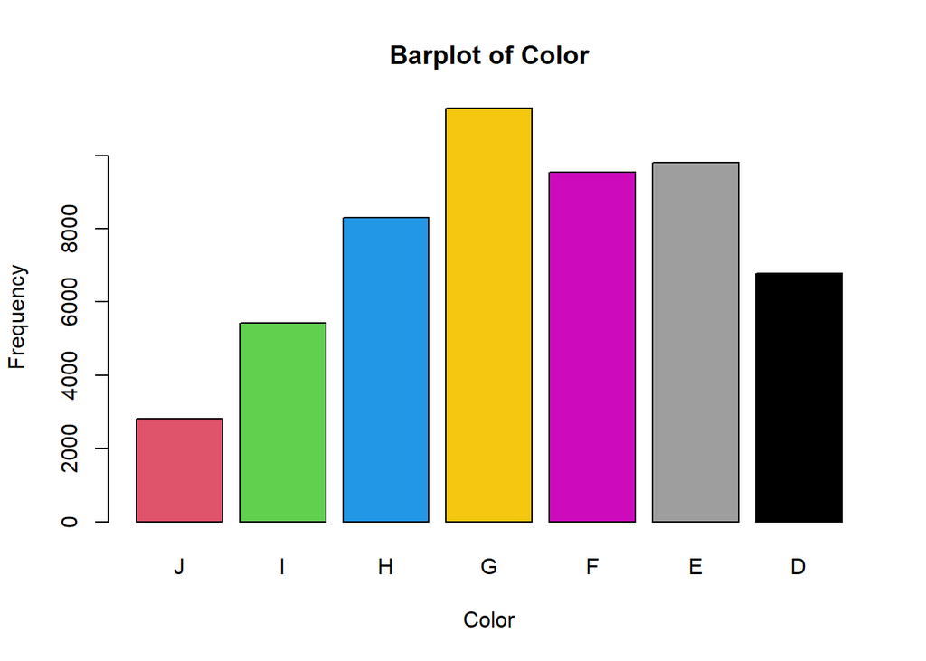

```r
barplot(table(diamonds$color), col = c(2, 3, 4, 7, 6, 8, 9), main = 'Barplot of Color', xlab = "Color", ylab = "Frequency")
```

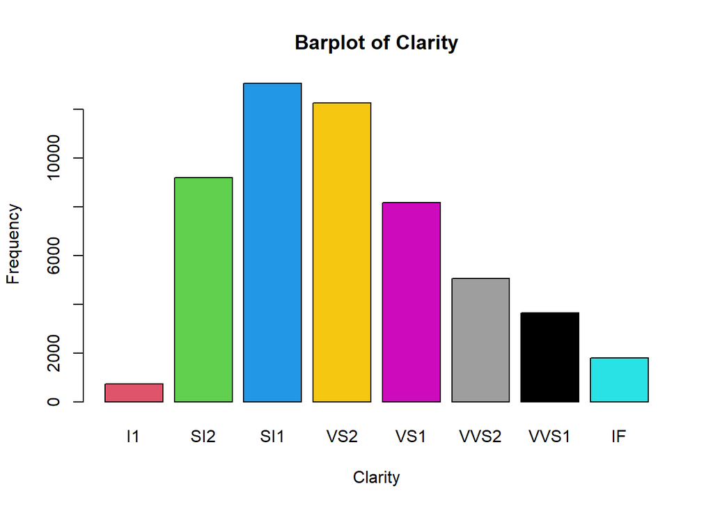

```r
barplot(table(diamonds$clarity), col = c(2, 3, 4, 7, 6, 8, 9, 5), main = 'Barplot of Clarity', xlab = "Clarity", ylab = "Frequency")
```

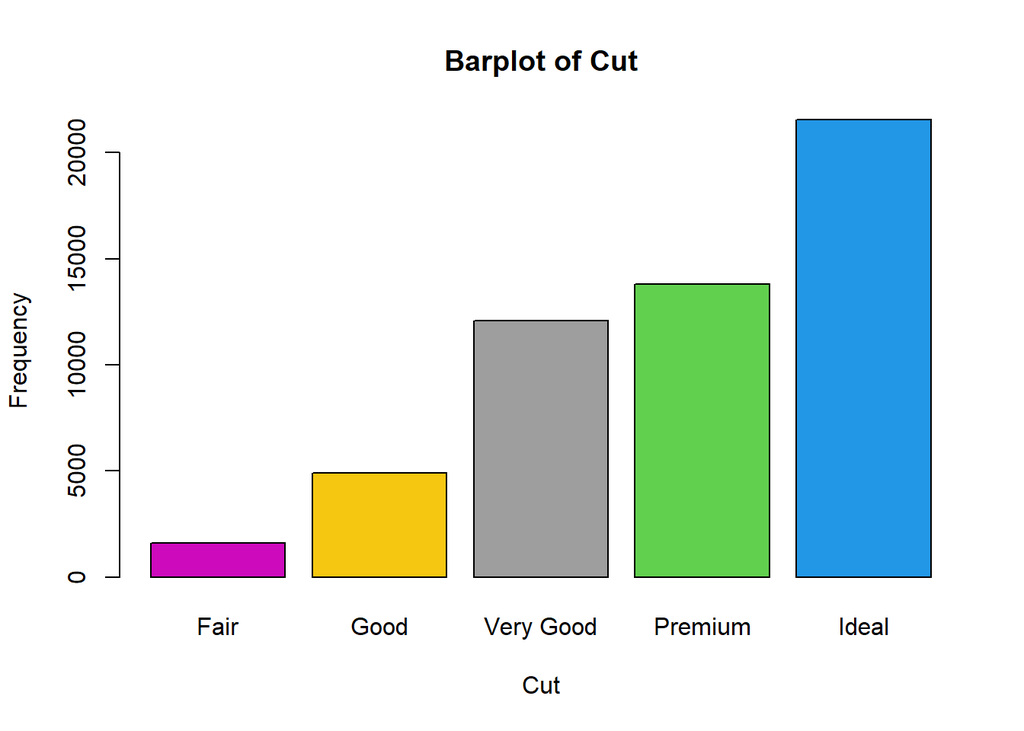

```r
barplot(table(diamonds$cut), col = c(6, 7, 8, 3, 4), main = 'Barplot of Cut', xlab = "Cut", ylab = "Frequency")
```

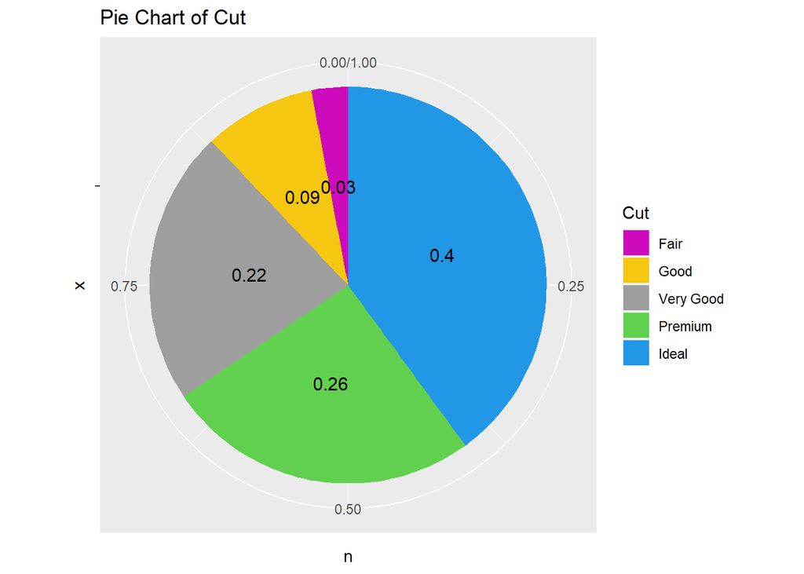

```r
cut_count = dplyr::count(diamonds, cut)
colnames(cut_count)[colnames(cut_count) == 'cut'] <- 'Cut'
cut_count$n = cut_count$n/sum(cut_count$n)

loadPkg("ggplot2")

ggplot(cut_count, aes(x = "", y = n, fill = Cut)) +
  geom_bar(stat="identity", width=1) +
  coord_polar("y", start=0) +
  geom_text(size = 4, aes(label = paste0(round(n, 2), "")), position = position_stack(vjust = 0.5))+
  scale_fill_manual(values = c(6, 7, 8, 3, 4))+
  labs(title='Pie Chart of Cut')
```

Cut has a different spread compared to the other two variables. In this case, the highest quantity of diamonds, 21551, are located at the top at the Ideal level. The least are located in the Fair level, only containing 1610 diamonds. As the level of cut increases, so do the quantity of diamonds in that level.

To better visualize the differences in cut, we also created a pie chart. Ideal diamonds make up 40% of the data. If you were to combine all Fair, Good, and Premium diamonds, there would still be more Ideal diamonds. This vast discrepancy should be noted when looking at the coming research.

### Continious Data Exploration

In this section we will look at all the continuous variables besides price.

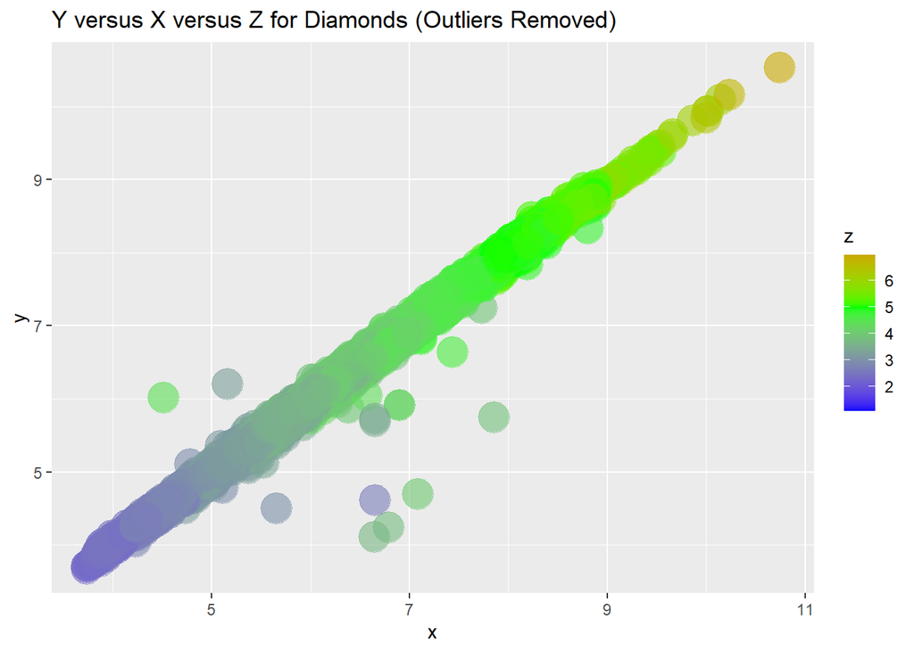

```r
diaNO = subset(diamonds, x > 0 & y > 0 & z > 0 & y <30 & z <30)
ggplot(diaNO, aes(x, y, color=z)) +
  geom_point(size = 8, alpha = 0.6) +
  ggtitle('Y versus X versus Z for Diamonds (Outliers Removed)') +
  scale_color_gradient2(midpoint = 5, low="blue", mid="green", high="red")
```

Here we can see a plot of x, y, and z, or the length, width, and depth of diamonds. The outliers are removed in this plot, so there are no values at zero or above thirty, in order to improve the readability of the plot. This plot shows a general trend in the data, that x, y, and z all increase and decrease together. In other words, higher x means higher y means higher z.

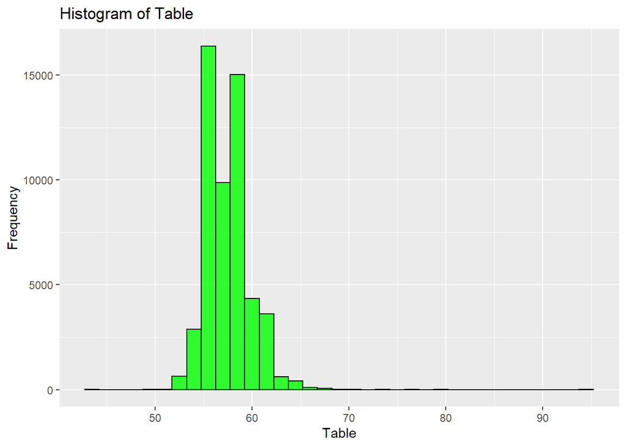

```r
ggplot(diamonds, aes(y=table)) +
  geom_histogram(col="black",
                 fill="green",
                  alpha = .8,
                 binwidth = 1.5) +
  labs(title='Histogram of Table') +
  coord_flip() +
  labs(y="Table", x="Frequency")
```

Table is the first of two extremely centralized variables, as can be seen from the histogram. The quantity of diamonds on the edges is so small, it cannot even be seen. The mean of table is 57.457 and the standard deviation is 2.234, which is reflected in the histogram.

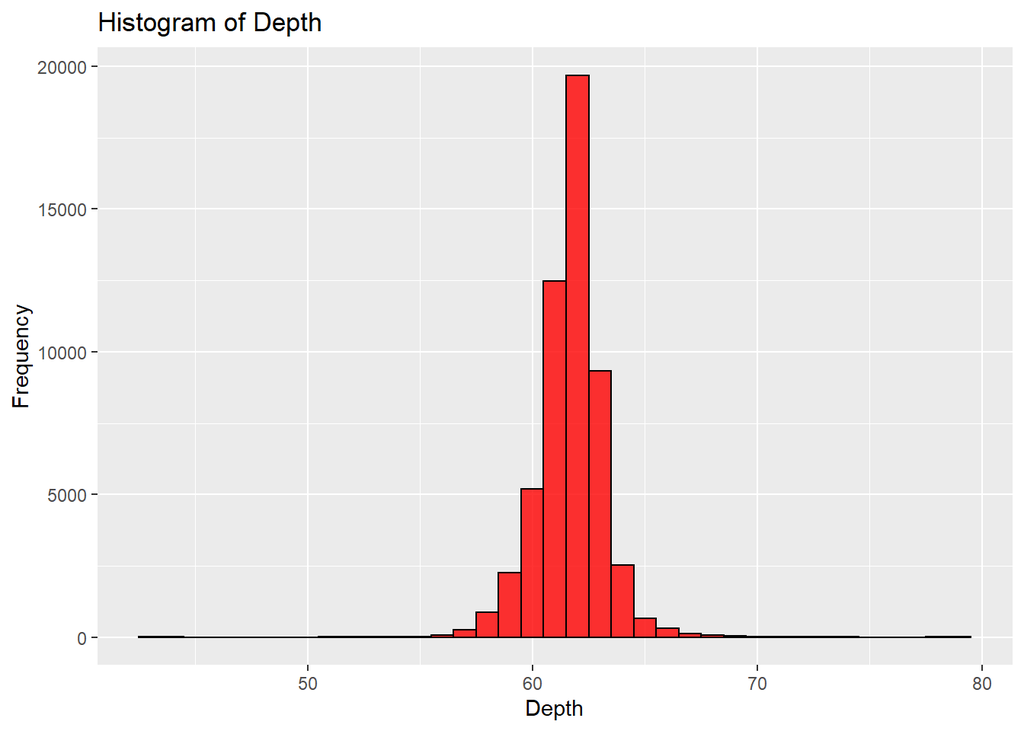

```r
ggplot(diamonds, aes(y=depth)) +
  geom_histogram(col="black",
                 fill="red",
                  alpha = .8,
                 binwidth = 1) +
  coord_flip() +
  labs(title='Histogram of Depth') +
  labs(y="Depth", x="Frequency")
```

Depth is the second of the extremely centralized variables. This is reflected again in the mean, 61.749, and the standard deviation, 1.433. This can also be seen in the histogram, with all of the data extremely centralized around the mean.

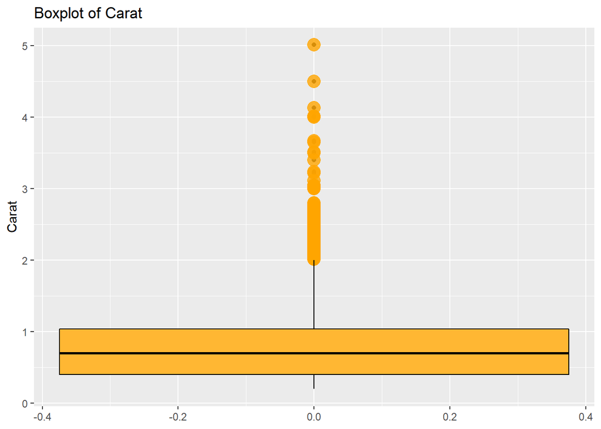

```r
ggplot(diamonds, aes(y=carat)) +
  geom_boxplot() +
  geom_boxplot(colour="black", fill="orange", outlier.colour="orange", outlier.size=5, alpha = 0.8) +
  labs(title = 'Boxplot of Carat')+
  labs(y="Carat")
```

Carat has a much different spread than table and depth, though the values are still grouped together. However, this time they are near the bottom, as every value above 2 is considered an outlier for carat. Overall, the carat distribution is extremely right skewed. The mean of carat is 0.798 and the standard deviation is 0.474.

### Price Exploration

Here are a couple plots on price.

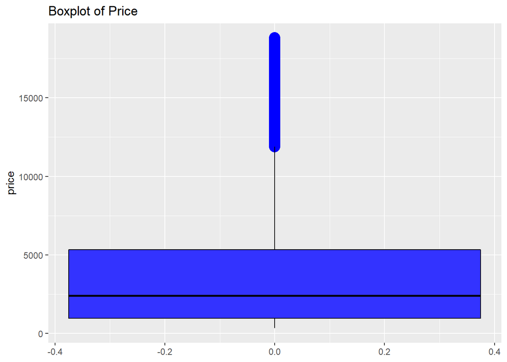

```r
ggplot(diamonds, aes(y=price)) +
  geom_boxplot() +
  geom_boxplot(colour="black", fill="blue", outlier.colour="blue", outlier.size=5, alpha = 0.8) +
  labs(title = 'Boxplot of Price')
```

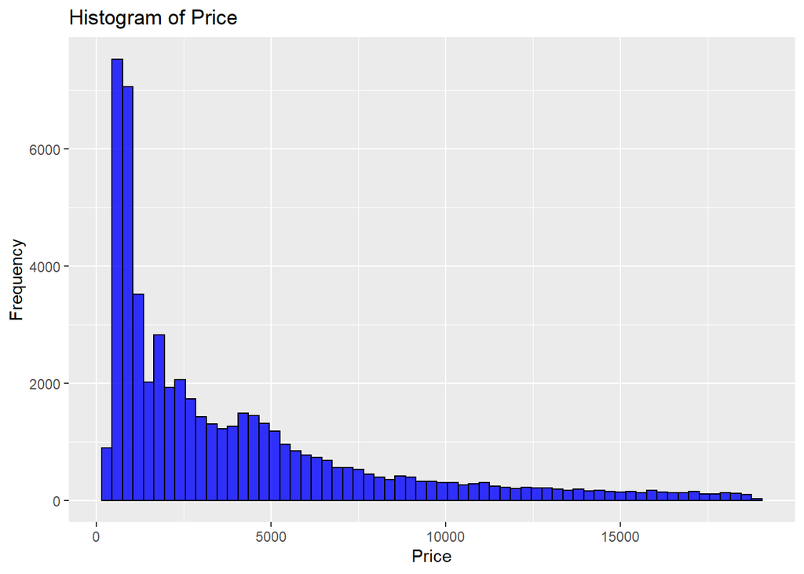

```r
ggplot(diamonds, aes(y=price)) +
  geom_histogram(col="black",
                 fill="blue",
                  alpha = .8,
                 binwidth = 300) +
  coord_flip() +
  labs(title='Histogram of Price') +
  labs(y="Price", x="Frequency")
```

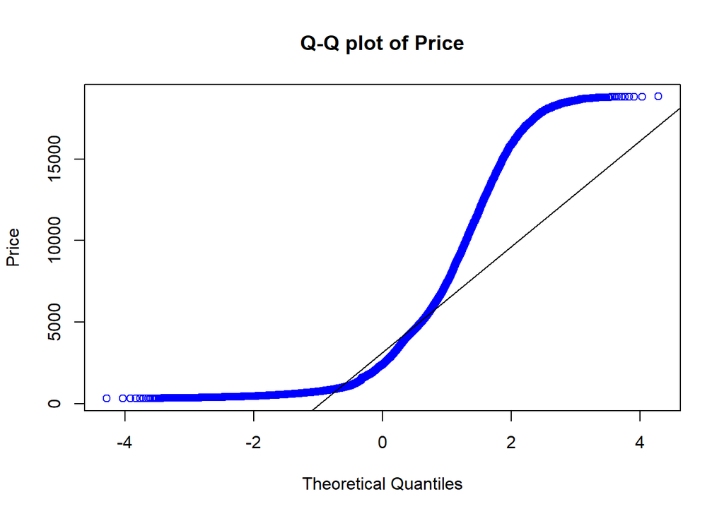

```r
qqnorm(diamonds$price, main="Q-Q plot of Price", col = 'blue', ylab = 'Price')
qqline(diamonds$price)
```

With the exploratory data analysis complete, we can move onto the SMART questions.

## How Do Categorical Variables Affect Price?

### Diamond CUT

The Diamonds data set have five `cut` types with the highest superscript indicating the best:

Fair<sup>1</sup> | Good<sup>2</sup> | Very Good<sup>3</sup> | Premium<sup>4</sup> | Ideal<sup>5</sup>

```r
loadPkg('viridis')

diamonds_outliers_removed<- outlierKD2(diamonds,price, TRUE,FALSE, FALSE, FALSE)
```

```r
# any(is.na.data.frame(diamonds)) colSums(is.na(diamonds))
cut <- subset(diamonds,select=c(cut))
xkabledply(table(cut),title = "Distinct Count of Cut Type",wide=TRUE)
```

Distinct Count of Cut Type

| Fair | Good | Very Good | Premium | Ideal |
| --- | --- | --- | --- | --- |
| 1610 | 4906 | 12082 | 13791 | 21551 |

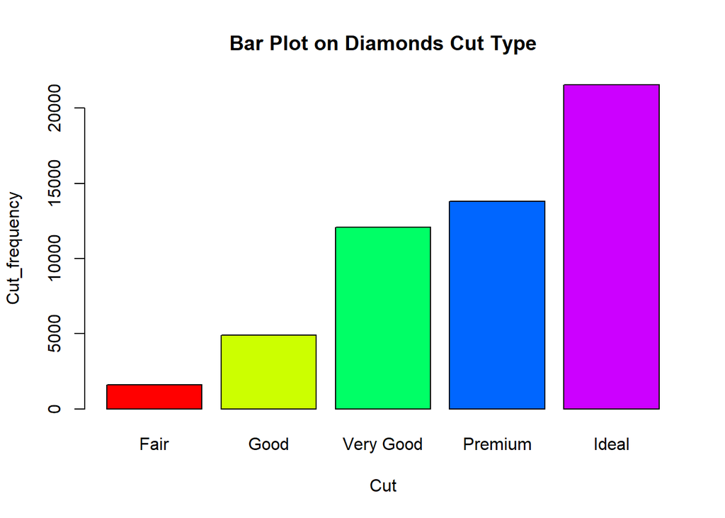

```r
barplot(table(cut),main = "Bar Plot on Diamonds Cut Type",xlab = "Cut",ylab = "Cut_frequency", col=rainbow(5))
```

It is noticed from the bar plot that most of the customers went for the `Ideal` Diamond cut which is `100%` from the cut scale (20% for each level of cut grade).

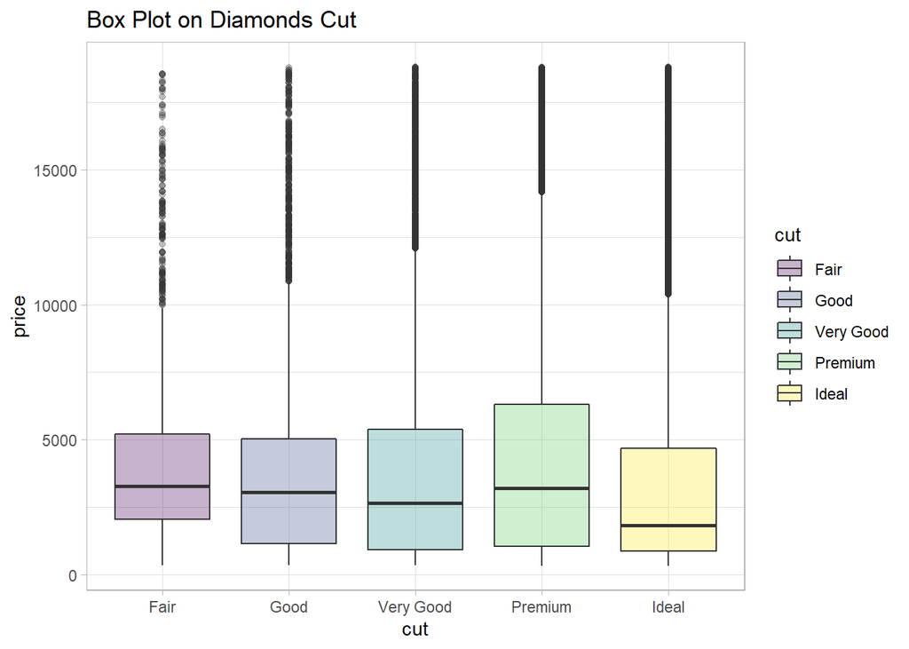

```r
loadPkg("ggridges")
ggplot(diamonds,aes(x=cut,y=price,fill=cut))+geom_boxplot(alpha=0.3)+theme_light()+ggtitle("Box Plot on Diamonds Cut")
```

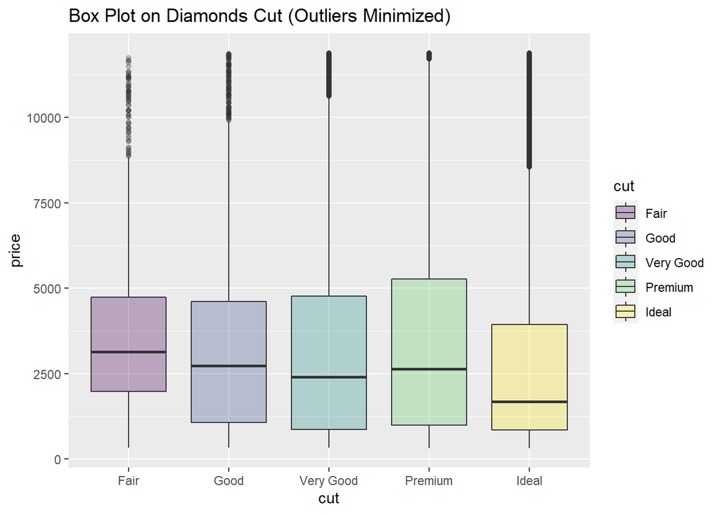

```r
ggplot(diamonds_outliers_removed,aes(x=cut,y=price,fill=cut))+geom_boxplot(alpha=0.3)+ggtitle("Box Plot on Diamonds Cut (Outliers Minimized)")
```

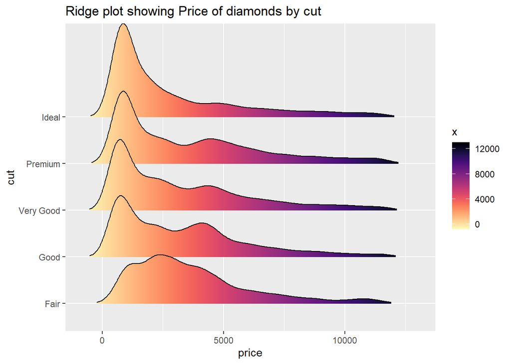

```r
ggplot(diamonds_outliers_removed, aes(x = price, y = cut, fill = ..x..))+ggridges::geom_density_ridges_gradient(scale = 2, rel_min_height = 0.01)+scale_fill_viridis(option = "A", direction = -1) + ggtitle("Ridge plot showing Price of diamonds by cut")
```

```r
caov <- aov(diamonds_outliers_removed$price~cut,data = diamonds_outliers_removed)
```

It can be noticed from the box plot that fair cut has the maximum median. The ridge plot gives a clear view that the means are higher than the median (positively skewed) and that most customers went for diamonds less than $5,000 regardless of cut type.

### ANOVA of Price and Cut

H<sub>0</sub> :There is no difference in the mean price across different diamonds cut

H<sub>1</sub> :There is difference in the mean price across different diamonds cut

```r
xkabledply(caov, title = "ANOVA Modelling of Price by Cut")
```

ANOVA Modelling of Price by Cut

|  | Df | Sum Sq | Mean Sq | F value | Pr(>F) |
| --- | --- | --- | --- | --- | --- |
| cut | 4 | 4.89e+09 | 1.22e+09 | 162 | 0 |
| Residuals | 50397 | 3.80e+11 | 7.55e+06 | NA | NA |

We reject H<sub>0</sub> from the ANOVA test between Diamonds price and cut with p-value `2E-16` as this shows that the mean price across different diamonds cut are different.

```r
TukeyCutAoV <- TukeyHSD(caov)
TukeyCutAoV
```

```
##   Tukey multiple comparisons of means
##     95% family-wise confidence level
##
## Fit: aov(formula = diamonds_outliers_removed$price ~ cut, data = diamonds_outliers_removed)
##
## $cut
##                     diff   lwr    upr p adj
## Good-Fair         -372.8  -595 -150.7 0.000
## Very Good-Fair    -419.6  -625 -214.2 0.000
## Premium-Fair      -124.4  -329   79.8 0.458
## Ideal-Fair        -856.7 -1057 -656.8 0.000
## Very Good-Good     -46.8  -177   83.8 0.866
## Premium-Good       248.4   120  377.1 0.000
## Ideal-Good        -483.9  -606 -362.0 0.000
## Premium-Very Good  295.2   198  392.3 0.000
## Ideal-Very Good   -437.1  -525 -349.3 0.000
## Ideal-Premium     -732.3  -817 -647.2 0.000
```

```r
model.tables(caov,"mean")
```

```
## Tables of means
## Grand mean
##
## 3160
##
##  cut
##     Fair Good Very Good Premium Ideal
##     3666 3293      3246    3542  2809
## rep 1509 4641     11325   12533 20394
```

We proceed to a post-hoc (Tukey HSD) test to uncover specific differences between the cut group means.

Our result shows that the pairs: Good-Fair | Very Good-Fair | Ideal-Fair | Premium-Good | Ideal-Good | Premium-Very Good | Ideal-Very Good | Ideal-Premium are significant with a p-value less than 0.05.

We can also infer that it is very likely (significant) for customers to purchase diamonds with `Fair`, `Good`, `Very Good`, `Premium` cut than `Ideal` cut type.

### Diamond COLOR

The Diamonds data set have seven `color` grades with the highest superscript indicating the best:

J<sup>1</sup> | I<sup>2</sup> | H<sup>3</sup> | G<sup>4</sup> | F<sup>5</sup> | E<sup>6</sup> | D<sup>7</sup>

```r
color<- subset(diamonds,select = c(color))
xkabledply((table(color)),title = "Distinct Count of Diamond's Color Grade",wide=TRUE)
```

Distinct Count of Diamond’s Color Grade

| J | I | H | G | F | E | D |
| --- | --- | --- | --- | --- | --- | --- |
| 2808 | 5422 | 8304 | 11292 | 9542 | 9797 | 6775 |

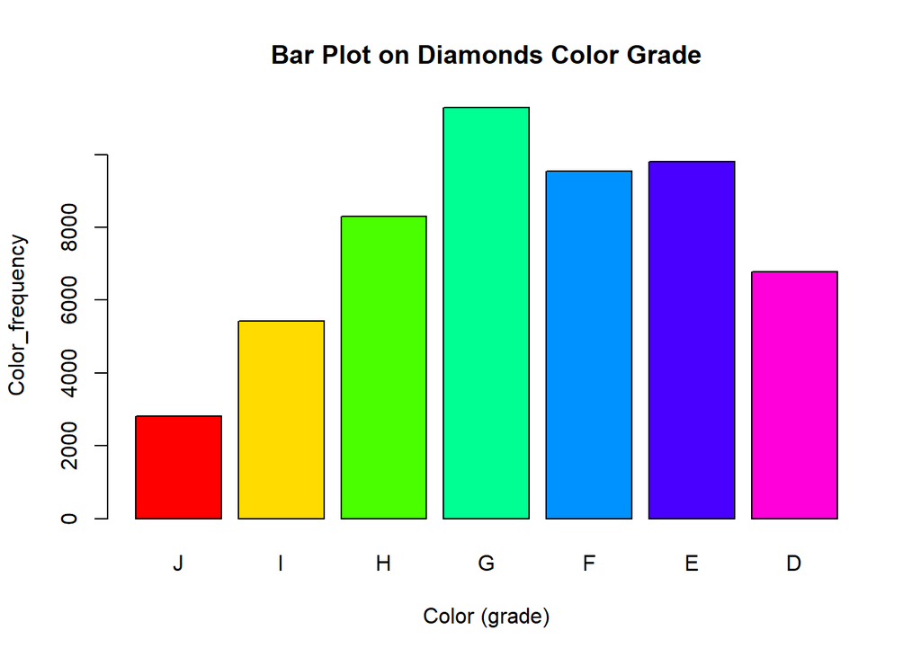

```r
barplot(table(color),main = "Bar Plot on Diamonds Color Grade",xlab = "Color (grade)",ylab = "Color_frequency", col=rainbow(7))
```

It is noticed from the bar plot that most of the customers went for the `G` Diamond color grade which is about `57.14%` from the clarity scale (~14.286% for each level of color grade).

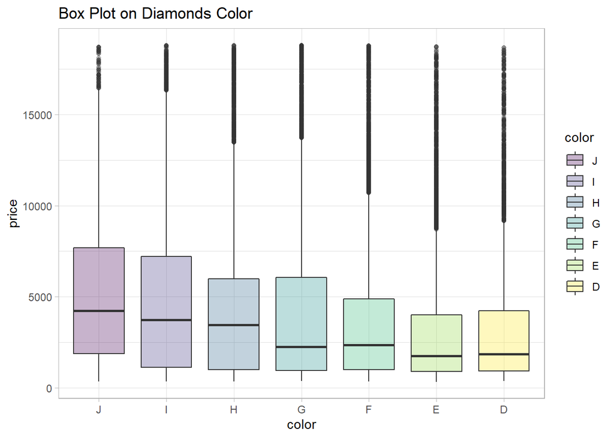

```r
ggplot(diamonds,aes(x=color,y=price,fill=color))+geom_boxplot(alpha=0.3)+theme_light()+ggtitle("Box Plot on Diamonds Color")
```

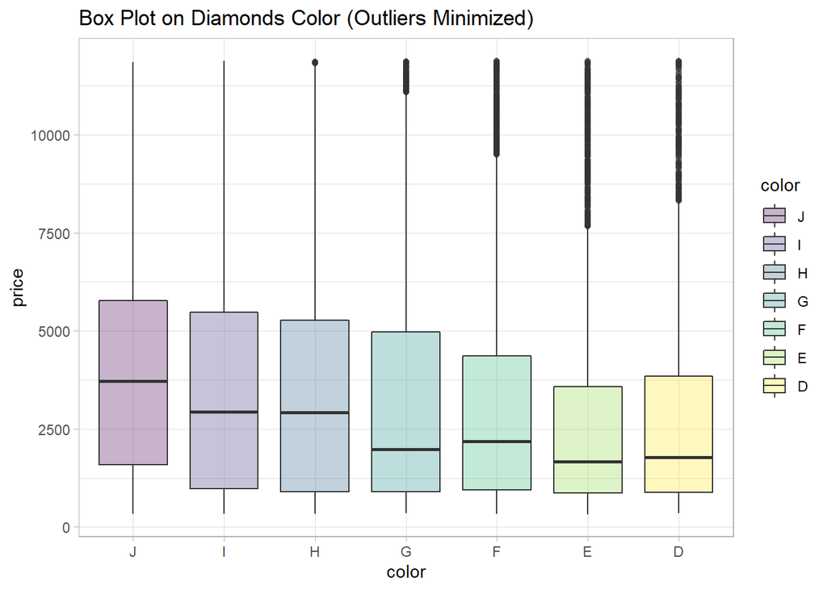

```r
ggplot(diamonds_outliers_removed,aes(x=color,y=price,fill=color))+geom_boxplot(alpha=0.3)+theme_light()+ggtitle("Box Plot on Diamonds Color (Outliers Minimized)")
```

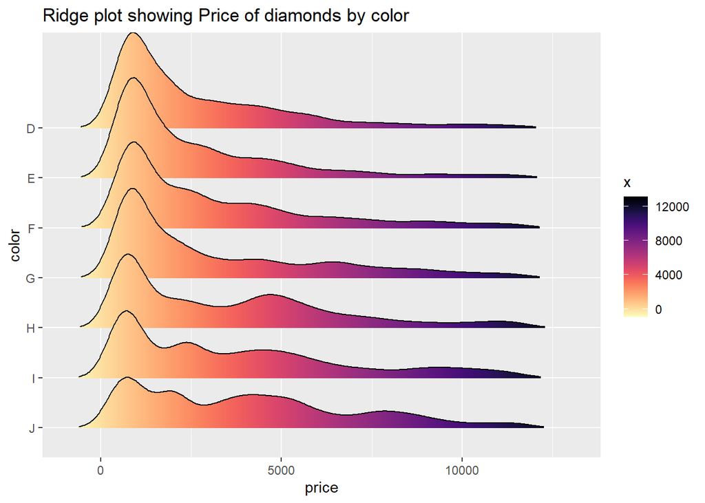

```r
ggplot(diamonds_outliers_removed, aes(x = price, y = color, fill = ..x..))+ggridges::geom_density_ridges_gradient(scale = 2, rel_min_height = 0.01)+scale_fill_viridis(option = "A", direction = -1) + ggtitle("Ridge plot showing Price of diamonds by color")
```

### ANOVA of Price and Color

H<sub>0</sub> :There is no difference in the mean price across different diamonds color grade

H<sub>1</sub> :There is difference in the mean price across different diamonds color grade

```r
caov2<- aov(diamonds_outliers_removed$price~color, data=diamonds_outliers_removed)
xkabledply(caov2, title = "ANOVA Modelling of Price by Color")
```

ANOVA Modelling of Price by Color

|  | Df | Sum Sq | Mean Sq | F value | Pr(>F) |
| --- | --- | --- | --- | --- | --- |
| color | 6 | 9.04e+09 | 1.51e+09 | 202 | 0 |
| Residuals | 50395 | 3.76e+11 | 7.47e+06 | NA | NA |

Also, we reject H<sub>0</sub> the ANOVA test between diamond price and color with p-value `2E-16` as this shows that the mean price across different diamonds colors are different.

```r
TukeyColorAoV <- TukeyHSD(caov2)
TukeyColorAoV
```

```
##   Tukey multiple comparisons of means
##     95% family-wise confidence level
##
## Fit: aov(formula = diamonds_outliers_removed$price ~ color, data = diamonds_outliers_removed)
##
## $color
##        diff     lwr     upr p adj
## I-J  -276.4  -476.3   -76.5 0.001
## H-J  -450.9  -637.8  -264.1 0.000
## G-J  -783.5  -964.0  -603.1 0.000
## F-J  -940.5 -1123.9  -757.2 0.000
## E-J -1403.7 -1586.2 -1221.2 0.000
## D-J -1325.5 -1516.2 -1134.7 0.000
## H-I  -174.5  -323.0   -26.0 0.010
## G-I  -507.1  -647.5  -366.8 0.000
## F-I  -664.1  -808.1  -520.1 0.000
## E-I -1127.3 -1270.2  -984.3 0.000
## D-I -1049.0 -1202.4  -895.7 0.000
## G-H  -332.6  -453.6  -211.6 0.000
## F-H  -489.6  -614.8  -364.3 0.000
## E-H  -952.8 -1076.8  -828.7 0.000
## D-H  -874.5 -1010.4  -738.6 0.000
## F-G  -157.0  -272.5   -41.5 0.001
## E-G  -620.1  -734.3  -506.0 0.000
## D-G  -541.9  -668.9  -414.9 0.000
## E-F  -463.2  -581.8  -344.5 0.000
## D-F  -385.0  -516.0  -253.9 0.000
## D-E    78.2   -51.6   208.1 0.564
```

```r
model.tables(caov2,"mean")
```

```
## Tables of means
## Grand mean
##
## 3160
##
##  color
##        J    I    H     G    F    E    D
##     4021 3744 3570  3237 3080 2617 2695
## rep 2457 4790 7641 10554 9023 9429 6508
```

From the grand means it shows that people are likely to spend more on poor colored type diamonds.

The Tukey post-hoc test for color grade groups, shows that the pairs are significant with p-value less than 0.05 except for `E-D` pair.

### Diamond CLARITY

The Diamonds data set has eight `clarity` grades with the highest superscript indicating the best:

I1<sup>1</sup> | SI2<sup>2</sup> | SI1<sup>3</sup> | VS2<sup>4</sup> | VS1<sup>5</sup> | VVS2<sup>6</sup> | VVS1<sup>7</sup> | IF<sup>8</sup>

```r
clarity<- subset(diamonds,select = c(clarity))
xkabledply((table(clarity)),title = "Distinct Count of Diamond's clarity",wide=TRUE)
```

Distinct Count of Diamond’s clarity

| I1 | SI2 | SI1 | VS2 | VS1 | VVS2 | VVS1 | IF |
| --- | --- | --- | --- | --- | --- | --- | --- |
| 741 | 9194 | 13065 | 12258 | 8171 | 5066 | 3655 | 1790 |

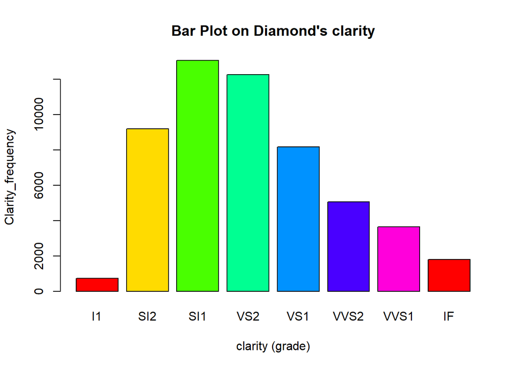

```r
barplot(table(clarity),main = "Bar Plot on Diamond's clarity",xlab = "clarity (grade)",ylab = "Clarity_frequency", col=rainbow(7))
```

It is noticed from the bar plot that most of the customers went for the `SI1` Diamond clarity type which is about `37.5%` clear from the clarity scale (12.5% for each level of clarity).

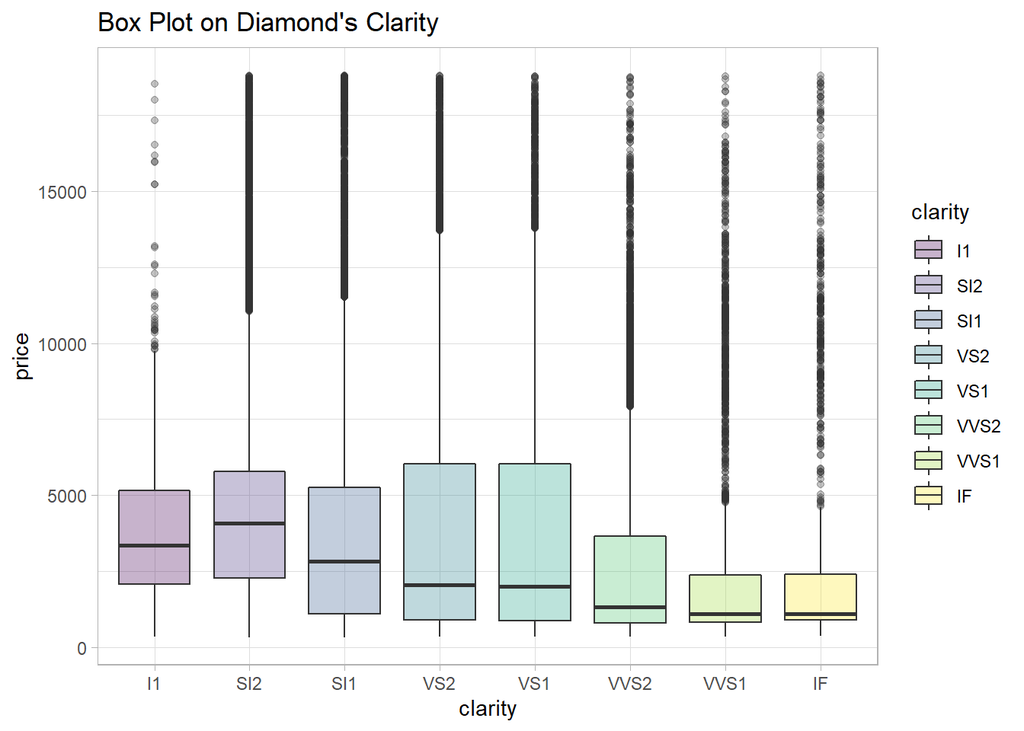

```r
ggplot(diamonds,aes(x=clarity,y=price,fill=clarity))+geom_boxplot(alpha=0.3)+theme_light()+ggtitle("Box Plot on Diamond's Clarity")
```

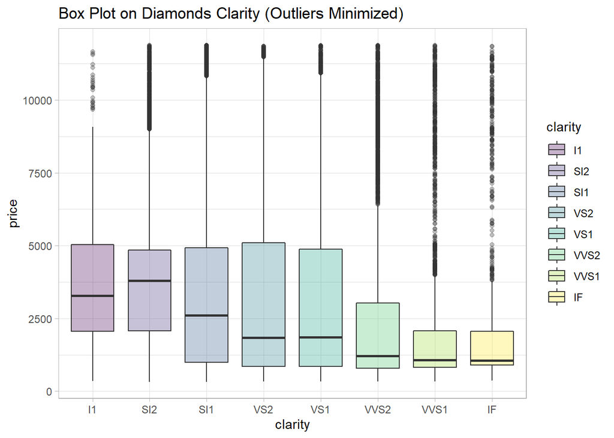

```r
ggplot(diamonds_outliers_removed,aes(x=clarity,y=price,fill=clarity))+geom_boxplot(alpha=0.3)+theme_light()+ggtitle("Box Plot on Diamonds Clarity (Outliers Minimized)")
```

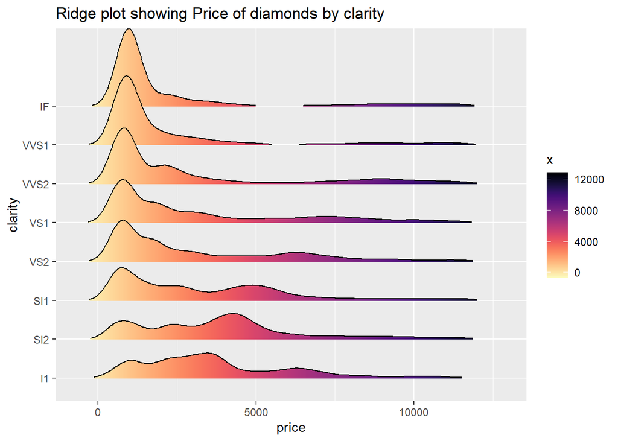

```r
ggplot(diamonds_outliers_removed, aes(x = price, y = clarity, fill = ..x..))+ggridges::geom_density_ridges_gradient(scale = 2, rel_min_height = 0.01)+scale_fill_viridis(option = "A", direction = -1) + ggtitle("Ridge plot showing Price of diamonds by clarity")
```

The clarity type ‘SI2’ has the highest median. Also, most customers went for diamonds less than $5,000 despite the clarity type.

### ANOVA of Price and Clarity

H<sub>0</sub> :There is no difference in the mean price across different diamonds clarity

H<sub>1</sub> :There is difference in the mean price across different diamonds clarity

```r
caov3<- aov(diamonds_outliers_removed$price~clarity, data=diamonds_outliers_removed)
xkabledply(caov3, title = "ANOVA Modelling of Price by Clarity")
```

ANOVA Modelling of Price by Clarity

|  | Df | Sum Sq | Mean Sq | F value | Pr(>F) |
| --- | --- | --- | --- | --- | --- |
| clarity | 7 | 1.07e+10 | 1.54e+09 | 206 | 0 |
| Residuals | 50394 | 3.75e+11 | 7.43e+06 | NA | NA |

We reject H<sub>0</sub> from the ANOVA test between diamonds price and clarity with p-value `2E-16` as this shows that the mean price across different diamonds clarity are different.

```r
TukeyClarityAoV <- TukeyHSD(caov3)
TukeyClarityAoV
```

```
##   Tukey multiple comparisons of means
##     95% family-wise confidence level
##
## Fit: aov(formula = diamonds_outliers_removed$price ~ clarity, data = diamonds_outliers_removed)
##
## $clarity
##               diff     lwr     upr p adj
## SI2-I1      150.24  -169.5   470.0 0.846
## SI1-I1     -413.94  -729.4   -98.5 0.002
## VS2-I1     -592.69  -908.8  -276.6 0.000
## VS1-I1     -551.11  -871.7  -230.5 0.000
## VVS2-I1    -917.25 -1245.9  -588.6 0.000
## VVS1-I1   -1585.56 -1922.1 -1249.0 0.000
## IF-I1     -1583.69 -1950.3 -1217.1 0.000
## SI1-SI2    -564.18  -682.0  -446.4 0.000
## VS2-SI2    -742.92  -862.5  -623.4 0.000
## VS1-SI2    -701.35  -832.4  -570.3 0.000
## VVS2-SI2  -1067.49 -1217.2  -917.8 0.000
## VVS1-SI2  -1735.80 -1902.0 -1569.6 0.000
## IF-SI2    -1733.93 -1954.8 -1513.0 0.000
## VS2-SI1    -178.74  -286.2   -71.3 0.000
## VS1-SI1    -137.17  -257.3   -17.0 0.013
## VVS2-SI1   -503.31  -643.5  -363.1 0.000
## VVS1-SI1  -1171.62 -1329.3 -1013.9 0.000
## IF-SI1    -1169.75 -1384.3  -955.2 0.000
## VS1-VS2      41.58   -80.3   163.4 0.969
## VVS2-VS2   -324.56  -466.2  -182.9 0.000
## VVS1-VS2   -992.87 -1151.9  -833.8 0.000
## IF-VS2     -991.00 -1206.6  -775.4 0.000
## VVS2-VS1   -366.14  -517.7  -214.6 0.000
## VVS1-VS1  -1034.45 -1202.3  -866.6 0.000
## IF-VS1    -1032.58 -1254.7  -810.4 0.000
## VVS1-VVS2  -668.31  -851.0  -485.6 0.000
## IF-VVS2    -666.44  -900.0  -432.8 0.000
## IF-VVS1       1.87  -242.6   246.4 1.000
```

```r
model.tables(caov3,"mean")
```

```
## Tables of means
## Grand mean
##
## 3160
##
##  clarity
##       I1  SI2   SI1   VS2  VS1 VVS2 VVS1   IF
##     3707 3857  3293  3114 3156 2790 2121 2123
## rep  727 8215 12275 11413 7700 4848 3537 1687
```

The grand means also made it clear that it is more likely for customers to spend more on lower/poorer clarity diamonds.

The post-hoc test made it clear that aside from these pairs SI2-I1, VS1-VS2, IF-VVS1 which are not significant; all other pairs are significantly different with p-value less than 0.05.

## How Do Continuous Variables Affect Price?

### T-tests for Different Intervals

```r
# T.test for continuous variables

diamonds_carat1 = subset(diamonds, carat < 1)
diamonds_carat2 = subset(diamonds, carat >= 1)

#two- sample ttest

t.test(diamonds_carat1$price, diamonds_carat2$price)
```

```
##
##  Welch Two Sample t-test
##
## data:  diamonds_carat1$price and diamonds_carat2$price
## t = -224, df = 20764, p-value <2e-16
## alternative hypothesis: true difference in means is not equal to 0
## 95 percent confidence interval:
##  -6566 -6453
## sample estimates:
## mean of x mean of y
##      1633      8142
```

```r
#for depth

diamonds_depth1 = subset(diamonds, depth < 61.7)
diamonds_depth2 = subset(diamonds, depth > 61.8)

#two- sample ttest

t.test(diamonds_depth1$price, diamonds_depth2$price)
```

```
##
##  Welch Two Sample t-test
##
## data:  diamonds_depth1$price and diamonds_depth2$price
## t = -1, df = 48413, p-value = 0.3
## alternative hypothesis: true difference in means is not equal to 0
## 95 percent confidence interval:
##  -109.3   31.7
## sample estimates:
## mean of x mean of y
##      3943      3982
```

```r
#for table

diamonds_table1 = subset(diamonds, table < 57.5)
diamonds_table2 = subset(diamonds, table > 57.5)

#two- sample ttest

t.test(diamonds_table1$price, diamonds_table2$price)
```

```
##
##  Welch Two Sample t-test
##
## data:  diamonds_table1$price and diamonds_table2$price
## t = -31, df = 48559, p-value <2e-16
## alternative hypothesis: true difference in means is not equal to 0
## 95 percent confidence interval:
##  -1153 -1017
## sample estimates:
## mean of x mean of y
##      3447      4532
```

```r
#for x


diamonds_x1 = subset(diamonds, x < 5.73)
diamonds_x2 = subset(diamonds, x > 5.73)

#two- sample ttest

t.test(diamonds_x1$price, diamonds_x2$price)
```

```
##
##  Welch Two Sample t-test
##
## data:  diamonds_x1$price and diamonds_x2$price
## t = -224, df = 27486, p-value <2e-16
## alternative hypothesis: true difference in means is not equal to 0
## 95 percent confidence interval:
##  -5695 -5596
## sample estimates:
## mean of x mean of y
##      1207      6852
```

```r
#for y


diamonds_y1 = subset(diamonds, y < 5.7)
diamonds_y2 = subset(diamonds, y > 5.7)

#two- sample ttest

t.test(diamonds_y1$price, diamonds_y2$price)
```

```
##
##  Welch Two Sample t-test
##
## data:  diamonds_y1$price and diamonds_y2$price
## t = -225, df = 28446, p-value <2e-16
## alternative hypothesis: true difference in means is not equal to 0
## 95 percent confidence interval:
##  -5593 -5496
## sample estimates:
## mean of x mean of y
##      1146      6691
```

```r
#for z

diamonds_z1 = subset(diamonds, z < 3.5)
diamonds_z2 = subset(diamonds, z > 3.5)

#two- sample ttest

t.test(diamonds_z1$price, diamonds_z2$price)
```

```
##
##  Welch Two Sample t-test
##
## data:  diamonds_z1$price and diamonds_z2$price
## t = -223, df = 29189, p-value <2e-16
## alternative hypothesis: true difference in means is not equal to 0
## 95 percent confidence interval:
##  -5518 -5422
## sample estimates:
## mean of x mean of y
##      1129      6598
```

From the t-tests above we can see that there is a significant difference in average price of diamond when we split the samples at the mean for variables such as carat, x, y, z and table. There is almost no difference in mean observed when we perform the two sample t-test for depth. From these tests we can get a sense of the correlations between price and other variables. Let us calculate the correlation matrix and plot a corrplot to see these relationships.

### Correlation Plot

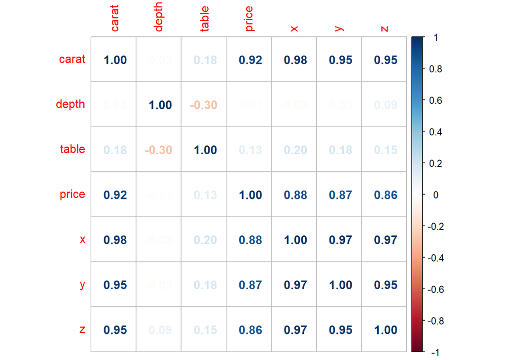

```r
# Creating a subset of continuous variables, calculating the correlation matrix and making the corrplot to identify the strongest relationships between continuous variables.

diamonds_continuous = subset(diamonds, select = c("carat", "depth", "table", "price", "x", "y", "z"))
loadPkg("corrplot")
diamonds_continuous_cor= cor(diamonds_continuous)
corrplot(diamonds_continuous_cor, method= "number")
```

```r
library(ggplot2)
library(car)
```

From the correlation matrix and corrplot we can see which variables have the strongest relationship with price of the diamond. We can see that carat and price have a very strong positive relationship followed by x, y, z and then table.

Let us build some linear models to explain the variation in price with respect to other variables.

### Linear Models

```r
fit1 <- lm(price ~ carat, data = diamonds)
summary(fit1)
```

```
##
## Call:
## lm(formula = price ~ carat, data = diamonds)
##
## Residuals:
##    Min     1Q Median     3Q    Max
## -18585   -805    -19    537  12732
##
## Coefficients:
##             Estimate Std. Error t value Pr(>|t|)
## (Intercept)  -2256.4       13.1    -173   <2e-16 ***
## carat         7756.4       14.1     551   <2e-16 ***
## ---
## Signif. codes:  0 '***' 0.001 '**' 0.01 '*' 0.05 '.' 0.1 ' ' 1
##
## Residual standard error: 1550 on 53938 degrees of freedom
## Multiple R-squared:  0.849,  Adjusted R-squared:  0.849
## F-statistic: 3.04e+05 on 1 and 53938 DF,  p-value: <2e-16
```

```r
xkabledply(fit1, title = paste("Model :", format(formula(fit1)) ) )
```

Model : price ~ carat

|  | Estimate | Std. Error | t value | Pr(>\|t\|) |
| --- | --- | --- | --- | --- |
| (Intercept) | -2256 | 13.1 | -173 | 0 |
| carat | 7756 | 14.1 | 551 | 0 |

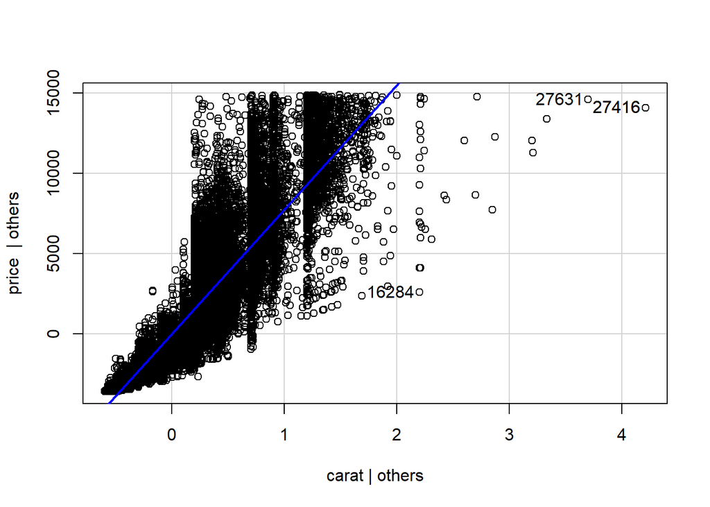

```r
avPlots(fit1)
```

```r
fit1a <- lm(price ~ x, data = diamonds)
summary(fit1a)
```

```
##
## Call:
## lm(formula = price ~ x, data = diamonds)
##
## Residuals:
##    Min     1Q Median     3Q    Max
##  -8426  -1264   -185    973  32128
##
## Coefficients:
##              Estimate Std. Error t value Pr(>|t|)
## (Intercept) -14094.06      41.73    -338   <2e-16 ***
## x             3145.41       7.15     440   <2e-16 ***
## ---
## Signif. codes:  0 '***' 0.001 '**' 0.01 '*' 0.05 '.' 0.1 ' ' 1
##
## Residual standard error: 1860 on 53938 degrees of freedom
## Multiple R-squared:  0.782,  Adjusted R-squared:  0.782
## F-statistic: 1.94e+05 on 1 and 53938 DF,  p-value: <2e-16
```

```r
xkabledply(fit1a, title = paste("Model :", format(formula(fit1a)) ) )
```

Model : price ~ x

|  | Estimate | Std. Error | t value | Pr(>\|t\|) |
| --- | --- | --- | --- | --- |
| (Intercept) | -14094 | 41.73 | -338 | 0 |
| x | 3145 | 7.15 | 440 | 0 |

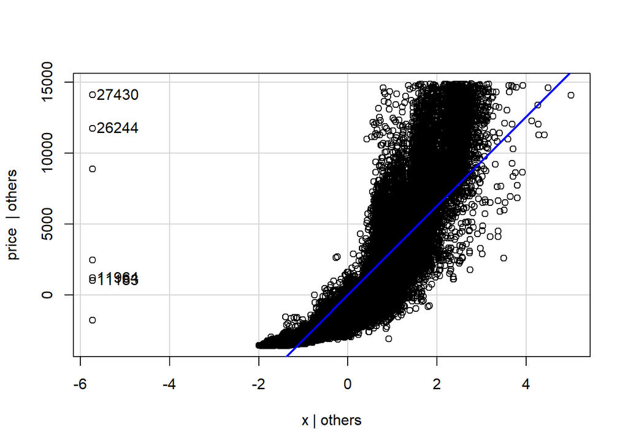

```r
avPlots(fit1a)
```

```r
fit1b <- lm(price ~ y, data = diamonds)
summary(fit1b)
```

```
##
## Call:
## lm(formula = price ~ y, data = diamonds)
##
## Residuals:
##     Min      1Q  Median      3Q     Max
## -152436   -1229    -241     838   31436
##
## Coefficients:
##              Estimate Std. Error t value Pr(>|t|)
## (Intercept) -13402.03      44.06    -304   <2e-16 ***
## y             3022.89       7.54     401   <2e-16 ***
## ---
## Signif. codes:  0 '***' 0.001 '**' 0.01 '*' 0.05 '.' 0.1 ' ' 1
##
## Residual standard error: 2000 on 53938 degrees of freedom
## Multiple R-squared:  0.749,  Adjusted R-squared:  0.749
## F-statistic: 1.61e+05 on 1 and 53938 DF,  p-value: <2e-16
```

```r
xkabledply(fit1b, title = paste("Model :", format(formula(fit1b)) ) )
```

Model : price ~ y

|  | Estimate | Std. Error | t value | Pr(>\|t\|) |
| --- | --- | --- | --- | --- |
| (Intercept) | -13402 | 44.06 | -304 | 0 |
| y | 3023 | 7.54 | 401 | 0 |

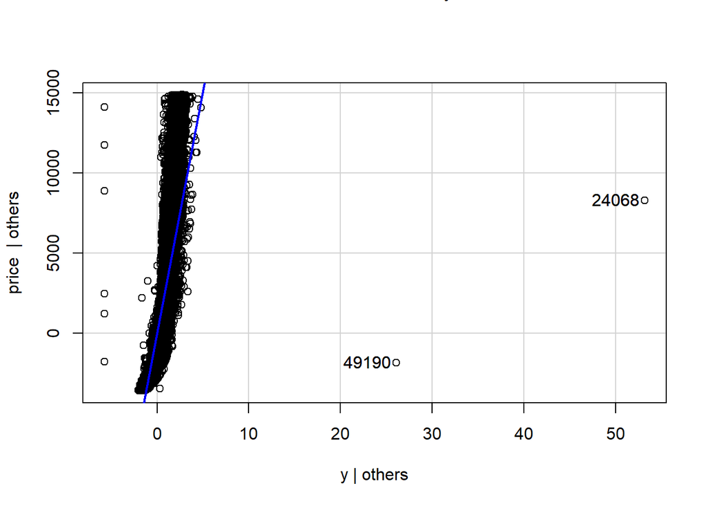

```r
avPlots(fit1b)
```

```r
fit1c <- lm(price ~ z, data = diamonds)
summary(fit1c)
```

```
##
## Call:
## lm(formula = price ~ z, data = diamonds)
##
## Residuals:
##     Min      1Q  Median      3Q     Max
## -139561   -1235    -240     825   32085
##
## Coefficients:
##             Estimate Std. Error t value Pr(>|t|)
## (Intercept) -13296.6       44.6    -298   <2e-16 ***
## z             4868.8       12.4     394   <2e-16 ***
## ---
## Signif. codes:  0 '***' 0.001 '**' 0.01 '*' 0.05 '.' 0.1 ' ' 1
##
## Residual standard error: 2030 on 53938 degrees of freedom
## Multiple R-squared:  0.742,  Adjusted R-squared:  0.742
## F-statistic: 1.55e+05 on 1 and 53938 DF,  p-value: <2e-16
```

```r
xkabledply(fit1c, title = paste("Model :", format(formula(fit1c)) ) )
```

Model : price ~ z

|  | Estimate | Std. Error | t value | Pr(>\|t\|) |
| --- | --- | --- | --- | --- |
| (Intercept) | -13297 | 44.6 | -298 | 0 |
| z | 4869 | 12.4 | 394 | 0 |

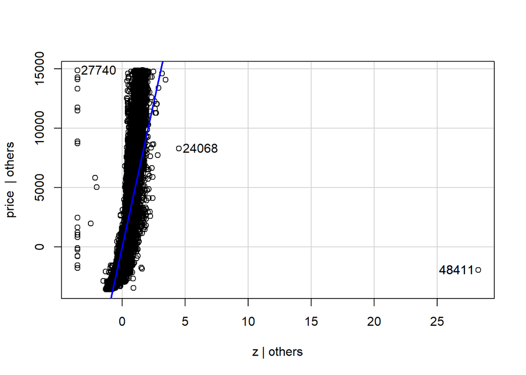

```r
avPlots(fit1c)
```

```r
fit1d <- lm(price ~ table, data = diamonds)
summary(fit1d)
```

```
##
## Call:
## lm(formula = price ~ table, data = diamonds)
##
## Residuals:
##    Min     1Q Median     3Q    Max
##  -6522  -2751  -1490   1368  15746
##
## Coefficients:
##             Estimate Std. Error t value Pr(>|t|)
## (Intercept) -9109.05     438.45   -20.8   <2e-16 ***
## table         226.98       7.63    29.8   <2e-16 ***
## ---
## Signif. codes:  0 '***' 0.001 '**' 0.01 '*' 0.05 '.' 0.1 ' ' 1
##
## Residual standard error: 3960 on 53938 degrees of freedom
## Multiple R-squared:  0.0162, Adjusted R-squared:  0.0161
## F-statistic:  886 on 1 and 53938 DF,  p-value: <2e-16
```

```r
xkabledply(fit1d, title = paste("Model :", format(formula(fit1c)) ) )
```

|  | Estimate | Std. Error | t value | Pr(>\|t\|) |
| --- | --- | --- | --- | --- |
| (Intercept) | -9109 | 438.45 | -20.8 | 0 |
| table | 227 | 7.63 | 29.8 | 0 |

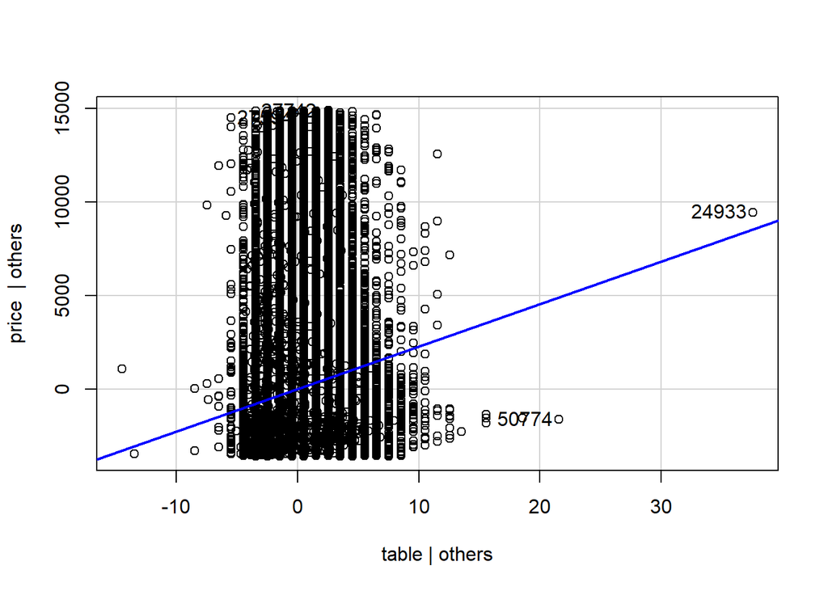

```r
avPlots(fit1d)
```

```r
fit2 <- lm(price ~ carat+x, data = diamonds)


xkabledply(fit2, title = paste("Model :", format(formula(fit2)) ) )
```

Model : price ~ carat + x

|  | Estimate | Std. Error | t value | Pr(>\|t\|) |
| --- | --- | --- | --- | --- |
| (Intercept) | 1738 | 103.6 | 16.8 | 0 |
| carat | 10126 | 62.6 | 161.9 | 0 |
| x | -1027 | 26.4 | -38.8 | 0 |

```r
xkablevif(fit2)
```

VIFs of the model

| carat | x |
| --- | --- |
| 20.3 | 20.3 |

```r
summary(fit2)
```

```
##
## Call:
## lm(formula = price ~ carat + x, data = diamonds)
##
## Residuals:
##    Min     1Q Median     3Q    Max
## -23423   -654    -14    371  12978
##
## Coefficients:
##             Estimate Std. Error t value Pr(>|t|)
## (Intercept)   1737.9      103.6    16.8   <2e-16 ***
## carat        10126.0       62.6   161.9   <2e-16 ***
## x            -1026.9       26.4   -38.9   <2e-16 ***
## ---
## Signif. codes:  0 '***' 0.001 '**' 0.01 '*' 0.05 '.' 0.1 ' ' 1
##
## Residual standard error: 1530 on 53937 degrees of freedom
## Multiple R-squared:  0.853,  Adjusted R-squared:  0.853
## F-statistic: 1.57e+05 on 2 and 53937 DF,  p-value: <2e-16
```

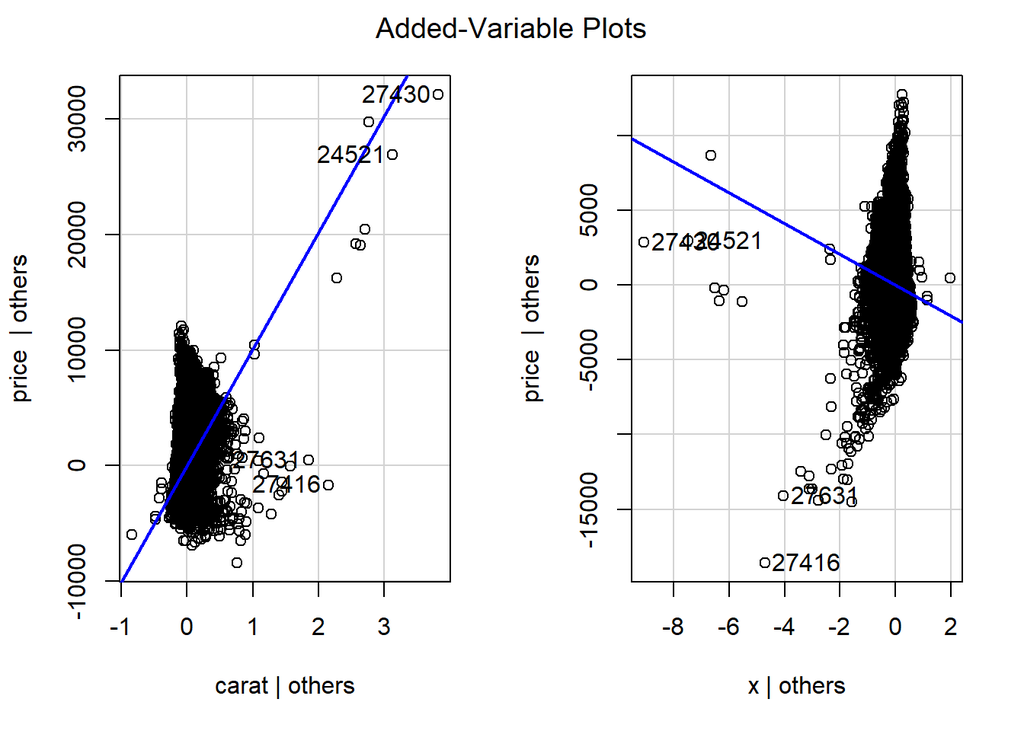

```r
avPlots(fit2)
```

```r
fit3 <- lm(price ~ carat+x+y, data = diamonds)


xkabledply(fit3, title = paste("Model :", format(formula(fit3)) ) )
```

Model : price ~ carat + x + y

|  | Estimate | Std. Error | t value | Pr(>\|t\|) |
| --- | --- | --- | --- | --- |
| (Intercept) | 1720 | 103.7 | 16.59 | 0 |
| carat | 10118 | 62.6 | 161.73 | 0 |
| x | -1149 | 36.3 | -31.64 | 0 |
| y | 126 | 25.8 | 4.89 | 0 |

```r
xkablevif(fit3)
```

VIFs of the model

| carat | x | y |
| --- | --- | --- |
| 20.3 | 38.4 | 20 |

```r
summary(fit3)
```

```
##
## Call:
## lm(formula = price ~ carat + x + y, data = diamonds)
##
## Residuals:
##    Min     1Q Median     3Q    Max
## -23385   -654    -14    371  12975
##
## Coefficients:
##             Estimate Std. Error t value Pr(>|t|)
## (Intercept)   1719.5      103.7   16.59   <2e-16 ***
## carat        10118.0       62.6  161.73   <2e-16 ***
## x            -1148.6       36.3  -31.64   <2e-16 ***
## y              126.0       25.8    4.89    1e-06 ***
## ---
## Signif. codes:  0 '***' 0.001 '**' 0.01 '*' 0.05 '.' 0.1 ' ' 1
##
## Residual standard error: 1530 on 53936 degrees of freedom
## Multiple R-squared:  0.853,  Adjusted R-squared:  0.853
## F-statistic: 1.05e+05 on 3 and 53936 DF,  p-value: <2e-16
```

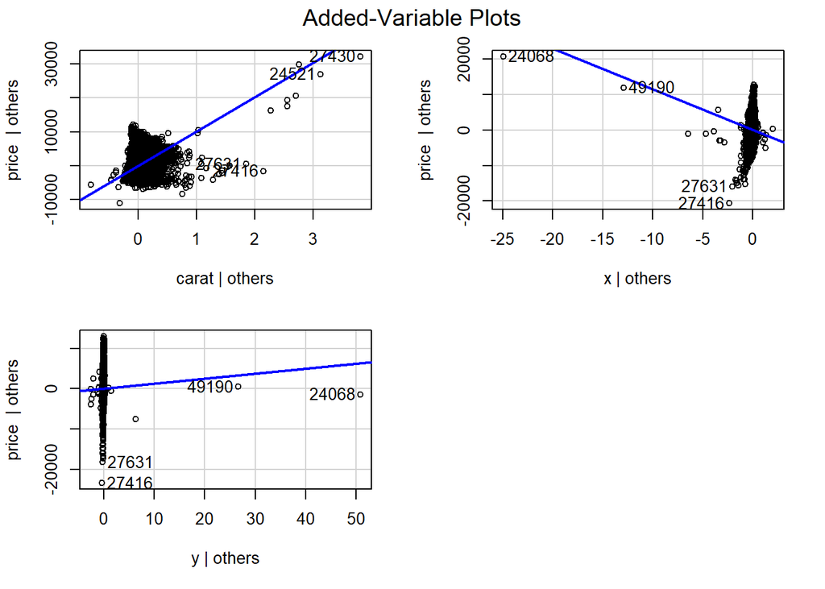

```r
avPlots(fit3)
```

```r
fit4 <- lm(price ~ carat+x+y+z, data = diamonds)


xkabledply(fit4, title = paste("Model :", format(formula(fit4)) ) )
```

Model : price ~ carat + x + y + z

|  | Estimate | Std. Error | t value | Pr(>\|t\|) |
| --- | --- | --- | --- | --- |
| (Intercept) | 1921 | 104.4 | 18.41 | 0 |
| carat | 10234 | 62.9 | 162.61 | 0 |
| x | -884 | 40.5 | -21.85 | 0 |
| y | 166 | 25.9 | 6.42 | 0 |
| z | -576 | 39.3 | -14.67 | 0 |

```r
xkablevif(fit4)
```

VIFs of the model

| carat | x | y | z |
| --- | --- | --- | --- |
| 20.7 | 47.9 | 20.3 | 17.8 |

```r
summary(fit4)
```

```
##
## Call:
## lm(formula = price ~ carat + x + y + z, data = diamonds)
##
## Residuals:
##    Min     1Q Median     3Q    Max
## -23407   -647    -16    358  16825
##
## Coefficients:
##             Estimate Std. Error t value Pr(>|t|)
## (Intercept)   1921.2      104.4   18.41  < 2e-16 ***
## carat        10233.9       62.9  162.61  < 2e-16 ***
## x             -884.2       40.5  -21.85  < 2e-16 ***
## y              166.0       25.9    6.42  1.4e-10 ***
## z             -576.2       39.3  -14.67  < 2e-16 ***
## ---
## Signif. codes:  0 '***' 0.001 '**' 0.01 '*' 0.05 '.' 0.1 ' ' 1
##
## Residual standard error: 1520 on 53935 degrees of freedom
## Multiple R-squared:  0.854,  Adjusted R-squared:  0.854
## F-statistic: 7.89e+04 on 4 and 53935 DF,  p-value: <2e-16
```

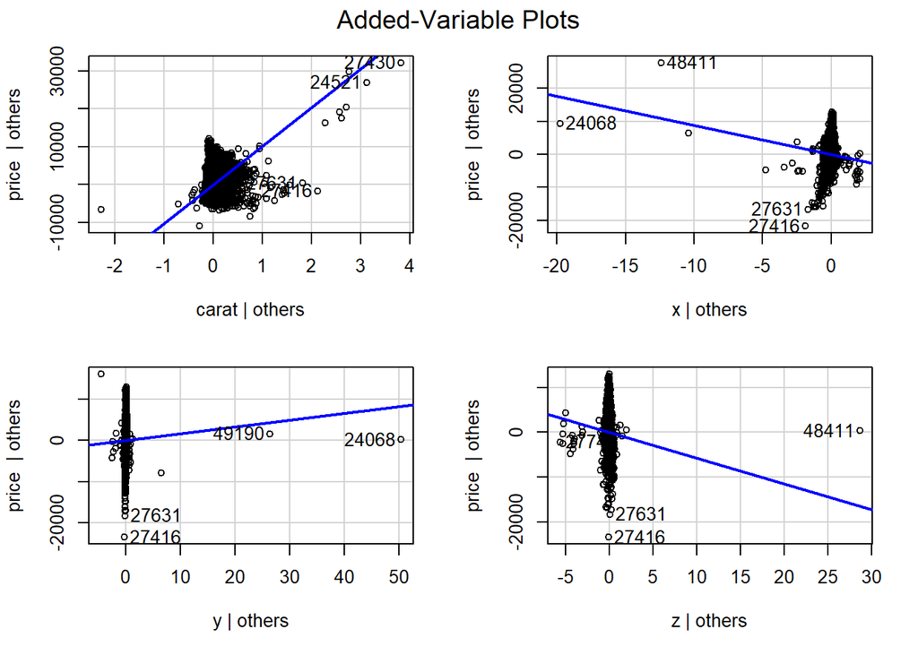

```r
avPlots(fit4)
```

```r
fit5 <- lm(price ~ carat+x+y+z+table, data = diamonds)


xkabledply(fit5, title = paste("Model :", format(formula(fit5)) ) )
```

Model : price ~ carat + x + y + z + table

|  | Estimate | Std. Error | t value | Pr(>\|t\|) |
| --- | --- | --- | --- | --- |
| (Intercept) | 5937.4 | 195.01 | 30.45 | 0 |
| carat | 10203.4 | 62.61 | 162.97 | 0 |
| x | -742.0 | 40.67 | -18.24 | 0 |
| y | 158.2 | 25.72 | 6.15 | 0 |
| z | -728.8 | 39.57 | -18.42 | 0 |
| table | -73.5 | 3.02 | -24.33 | 0 |

```r
xkablevif(fit5)
```

VIFs of the model

[output not shown]

```r
summary(fit5)
```

```
##
## Call:
## lm(formula = price ~ carat + x + y + z + table, data = diamonds)
##
## Residuals:
##    Min     1Q Median     3Q    Max
## -23314   -642    -33    364  21009
##
## Coefficients:
##             Estimate Std. Error t value Pr(>|t|)
## (Intercept)  5937.40     195.01   30.45  < 2e-16 ***
## carat       10203.40      62.61  162.97  < 2e-16 ***
## x            -742.05      40.67  -18.24  < 2e-16 ***
## y             158.19      25.72    6.15  7.8e-10 ***
## z            -728.83      39.57  -18.42  < 2e-16 ***
## table         -73.47       3.02  -24.33  < 2e-16 ***
## ---
## Signif. codes:  0 '***' 0.001 '**' 0.01 '*' 0.05 '.' 0.1 ' ' 1
##
## Residual standard error: 1520 on 53934 degrees of freedom
## Multiple R-squared:  0.856,  Adjusted R-squared:  0.856
## F-statistic: 6.39e+04 on 5 and 53934 DF,  p-value: <2e-16
```

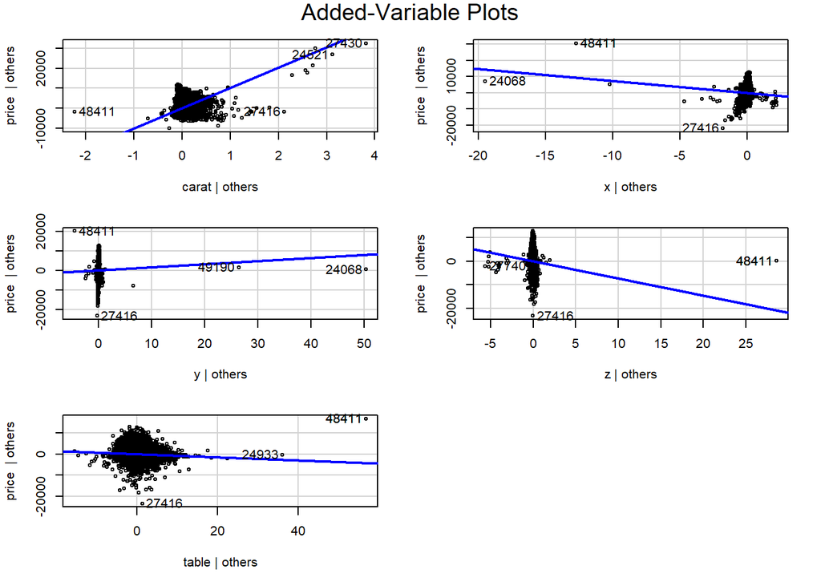

```r
avPlots(fit5)
```

```r
anova(fit1, fit1a, fit1b, fit1c, fit1d, fit2,fit3, fit4, fit5) -> anovaRes
anovaRes
```

```
## Analysis of Variance Table
##
## Model 1: price ~ carat
## Model 2: price ~ x
## Model 3: price ~ y
## Model 4: price ~ z
## Model 5: price ~ table
## Model 6: price ~ carat + x
## Model 7: price ~ carat + x + y
## Model 8: price ~ carat + x + y + z
## Model 9: price ~ carat + x + y + z + table
##   Res.Df      RSS Df Sum of Sq        F  Pr(>F)
## 1  53938 1.29e+11
## 2  53938 1.87e+11  0 -5.76e+10
## 3  53938 2.16e+11  0 -2.86e+10
## 4  53938 2.22e+11  0 -6.18e+09
## 5  53938 8.45e+11  0 -6.23e+11
## 6  53937 1.26e+11  1  7.19e+11 312858.6 < 2e-16 ***
## 7  53936 1.26e+11  1  5.58e+07     24.3 8.4e-07 ***
## 8  53935 1.25e+11  1  5.00e+08    217.5 < 2e-16 ***
## 9  53934 1.24e+11  1  1.36e+09    591.9 < 2e-16 ***
## ---
## Signif. codes:  0 '***' 0.001 '**' 0.01 '*' 0.05 '.' 0.1 ' ' 1
```

```r
str(anovaRes)
```

```
## Classes 'anova' and 'data.frame':    9 obs. of  6 variables:
##  $ Res.Df   : num  53938 53938 53938 53938 53938 ...
##  $ RSS      : num  1.29e+11 1.87e+11 2.16e+11 2.22e+11 8.45e+11 ...
##  $ Df       : num  NA 0 0 0 0 1 1 1 1
##  $ Sum of Sq: num  NA -5.76e+10 -2.86e+10 -6.18e+09 -6.23e+11 ...
##  $ F        : num  NA NA NA NA NA ...
##  $ Pr(>F)   : num  NA NA NA NA NA ...
##  - attr(*, "heading")= chr [1:2] "Analysis of Variance Table\n" "Model 1: price ~ carat\nModel 2: price ~ x\nModel 3: price ~ y\nModel 4: price ~ z\nModel 5: price ~ table\nMod"| __truncated__
```

```r
xkabledply(anovaRes, title = "ANOVA comparison between the models")
```

ANOVA comparison between the models

| Res.Df | RSS | Df | Sum of Sq | F | Pr(>F) |
| --- | --- | --- | --- | --- | --- |
| 53938 | 1.29e+11 | NA | NA | NA | NA |
| 53938 | 1.87e+11 | 0 | -5.76e+10 | NA | NA |
| 53938 | 2.16e+11 | 0 | -2.86e+10 | NA | NA |
| 53938 | 2.22e+11 | 0 | -6.18e+09 | NA | NA |
| 53938 | 8.45e+11 | 0 | -6.23e+11 | NA | NA |
| 53937 | 1.26e+11 | 1 | 7.19e+11 | 312858.6 | 0 |
| 53936 | 1.26e+11 | 1 | 5.58e+07 | 24.3 | 0 |
| 53935 | 1.25e+11 | 1 | 5.00e+08 | 217.5 | 0 |
| 53934 | 1.24e+11 | 1 | 1.36e+09 | 591.9 | 0 |

## How Do Categorical Variables Affect Cut?

After exploring what affects the price of diamonds, we are very interested in the cutting method of the diamonds. As we all know, considering that the better the cutting method, the higher the cost, it seems that the higher the quality of the raw material, the more likely it is to adopt the perfect cutting method.

In this dataset, clarity and color can represent the quality of the raw material.

### SMART Question: Do different ranks of clarity have different cutting methods?

Below is the statistics table of clarity and cutting method. All kinds of cutting methods are adopted in all ranks of clarity. But the percentage of each cutting methods may be different in different ranks of clarity.

```r
tab_cut_cla = table(diamonds$clarity,diamonds$cut)
xkabledply(tab_cut_cla,title = "Statistics Table of Clarity VS Cut")
```

Statistics Table of Clarity VS Cut

|  | Fair | Good | Very Good | Premium | Ideal |
| --- | --- | --- | --- | --- | --- |
| I1 | 210 | 96 | 84 | 205 | 146 |
| SI2 | 466 | 1081 | 2100 | 2949 | 2598 |
| SI1 | 408 | 1560 | 3240 | 3575 | 4282 |
| VS2 | 261 | 978 | 2591 | 3357 | 5071 |
| VS1 | 170 | 648 | 1775 | 1989 | 3589 |
| VVS2 | 69 | 286 | 1235 | 870 | 2606 |
| VVS1 | 17 | 186 | 789 | 616 | 2047 |
| IF | 9 | 71 | 268 | 230 | 1212 |

So, we draw pie charts of each rank of clarity. As the below charts shows, the worst rank of clarity (I1) uses the worst cutting method (fair) the most, but the best rank of clarity (IF) uses the best cutting method (ideal) the most.

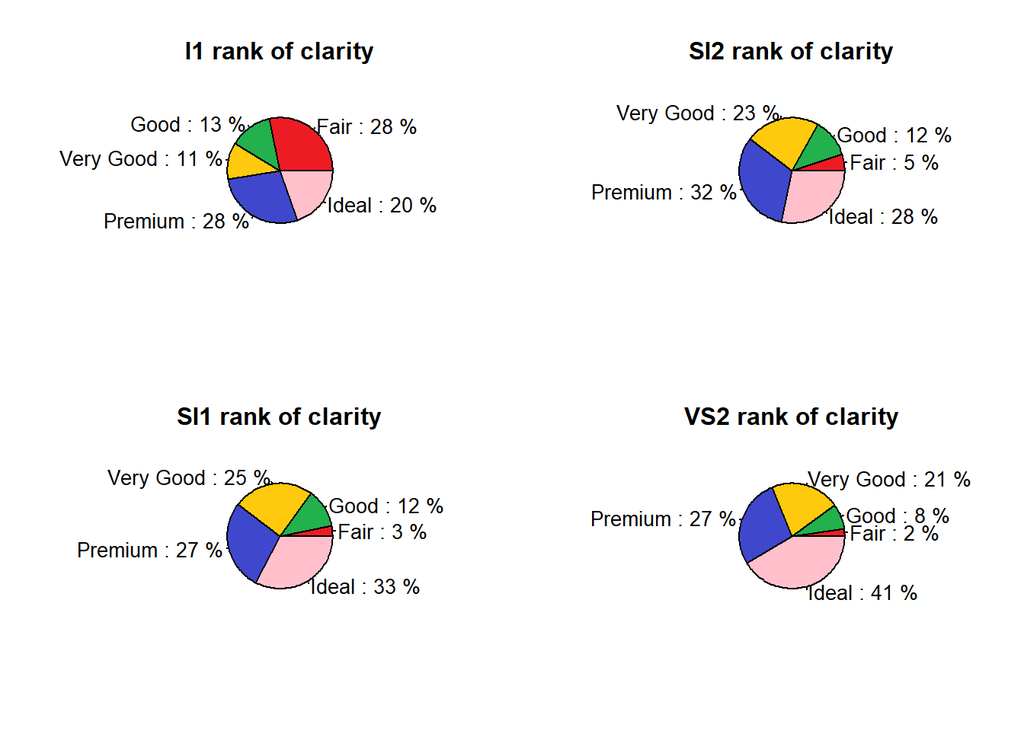

```r
names = colnames(tab_cut_cla)
cols = c("#ED1C24","#22B14C","#FFC90E","#3f48CC","pink")
piepercent_1 = paste(names,":",round(100*tab_cut_cla[1,]/sum(tab_cut_cla[1,])), "%")
piepercent_2 = paste(names,":",round(100*tab_cut_cla[2,]/sum(tab_cut_cla[2,])), "%")
piepercent_3 = paste(names,":",round(100*tab_cut_cla[3,]/sum(tab_cut_cla[3,])), "%")
piepercent_4 = paste(names,":",round(100*tab_cut_cla[4,]/sum(tab_cut_cla[4,])), "%")
piepercent_5 = paste(names,":",round(100*tab_cut_cla[5,]/sum(tab_cut_cla[5,])), "%")
piepercent_6 = paste(names,":",round(100*tab_cut_cla[6,]/sum(tab_cut_cla[6,])), "%")
piepercent_7 = paste(names,":",round(100*tab_cut_cla[7,]/sum(tab_cut_cla[7,])), "%")
piepercent_8 = paste(names,":",round(100*tab_cut_cla[8,]/sum(tab_cut_cla[8,])), "%")
par(mfrow=c(2,2))
pie(tab_cut_cla[1,], labels=piepercent_1, main = "I1 rank of clarity", col=cols)
pie(tab_cut_cla[2,], labels=piepercent_2, main = "SI2 rank of clarity", col=cols)
pie(tab_cut_cla[3,], labels=piepercent_3, main = "SI1 rank of clarity", col=cols)
pie(tab_cut_cla[4,], labels=piepercent_4, main = "VS2 rank of clarity", col=cols)
```

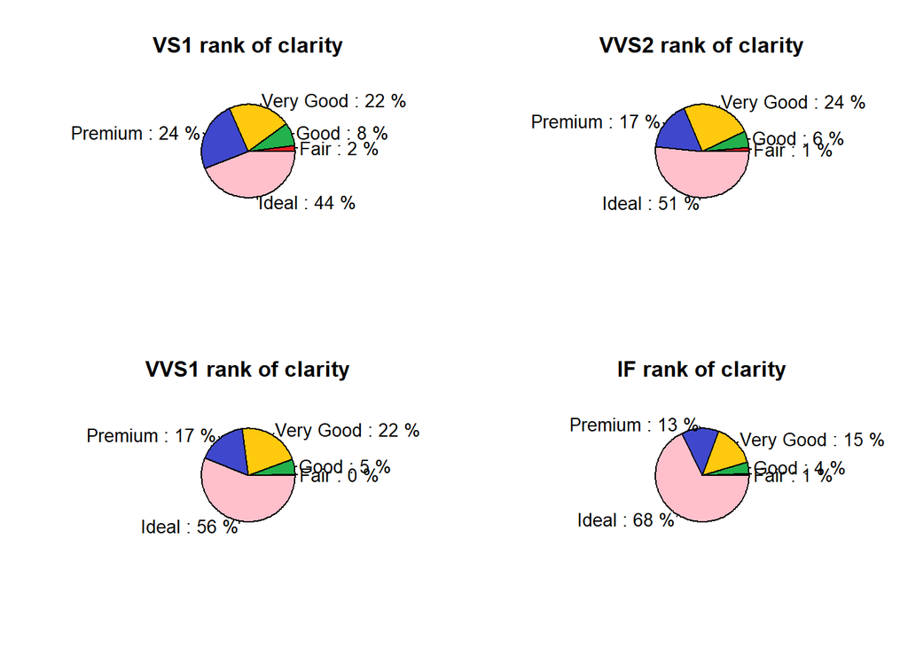

```r
pie(tab_cut_cla[5,], labels=piepercent_5, main = "VS1 rank of clarity", col=cols)
pie(tab_cut_cla[6,], labels=piepercent_6, main = "VVS2 rank of clarity", col=cols)
pie(tab_cut_cla[7,], labels=piepercent_7, main = "VVS1 rank of clarity", col=cols)
pie(tab_cut_cla[8,], labels=piepercent_8, main = "IF rank of clarity", col=cols)
```

Or we can turn the pie charts to one bar chart.

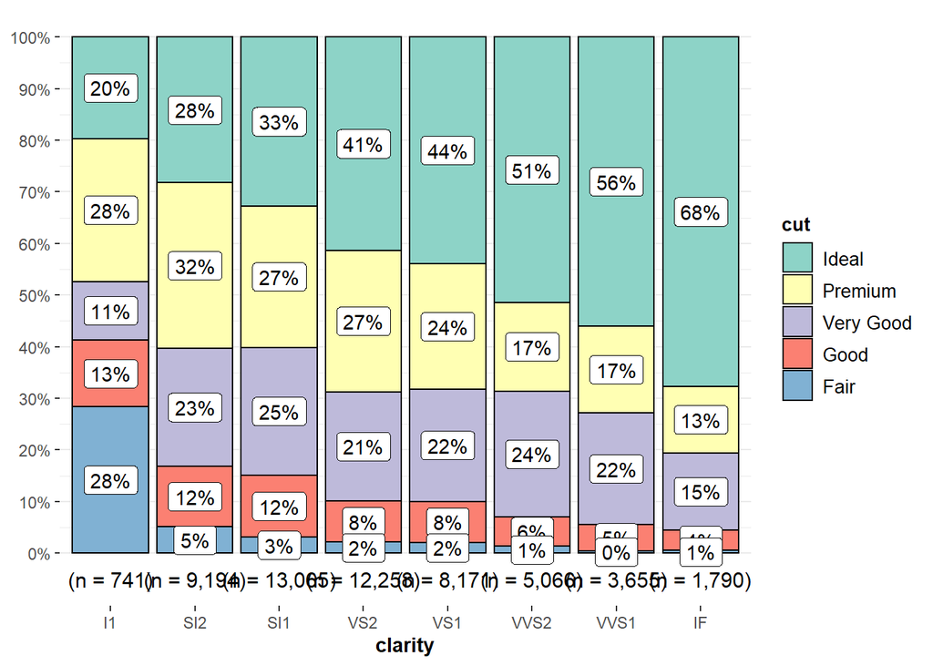

```r
loadPkg("ggstatsplot")
p = ggbarstats(data = diamonds, x = cut, y = clarity,results.subtitle = F,palette = "Set3", bar.proptest= F)
p
```

This bar chart shows the percentages of each cutting methods in each rank of clarity. It is clear that, with the rise of clarity ranks (from I1 to IF), the percentage of ideal cutting methods continues to increase and the percentage of fair cutting methods keeps decreasing.  
It seems that good ranks of clarity use good cutting methods.  
In order to obtain evidence to support our conclusion, we performed a Chi-squared test. The result is below. Because the p-value is too small, we have enough evidence to conclude that clarity of diamonds does affect the cutting methods.

```r
chitest_cut_cla = chisq.test(tab_cut_cla)
chitest_cut_cla
```

```
##
##  Pearson's Chi-squared test
##
## data:  tab_cut_cla
## X-squared = 4391, df = 28, p-value <2e-16
```

### SMART Question: Do different ranks of color have different cutting methods?

Below is the statistics table of color and cutting methods. All kinds of cutting methods are adopted in all ranks of color. But the percentage of each cutting methods may be different in different ranks of color.

```r
tab_cut_col = table(diamonds$color,diamonds$cut)
xkabledply(tab_cut_col,title = "Statistics Table of Color VS Cut")
```

[output not shown]

So, we draw pie charts of each rank of clarity. As the below charts shows, the percentages of each cutting methods are different in different ranks of color. Rank D is the best rank of color and rank J is the worst. Higher ranks of colors uses higher percentage of premium and ideal cutting methods.

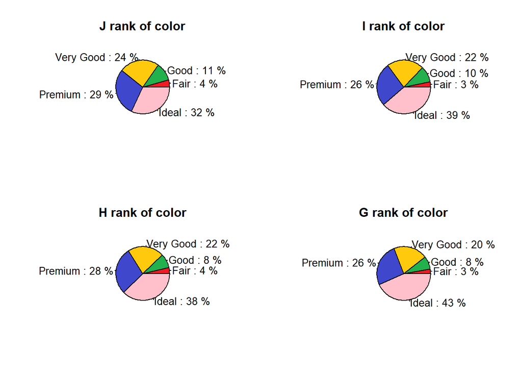

```r
names = colnames(tab_cut_col)
cols = c("#ED1C24","#22B14C","#FFC90E","#3f48CC","pink")
piepercent_j = paste(names,":",round(100*tab_cut_col[1,]/sum(tab_cut_col[1,])), "%")
piepercent_i = paste(names,":",round(100*tab_cut_col[2,]/sum(tab_cut_col[2,])), "%")
piepercent_h = paste(names,":",round(100*tab_cut_col[3,]/sum(tab_cut_col[3,])), "%")
piepercent_g = paste(names,":",round(100*tab_cut_col[4,]/sum(tab_cut_col[4,])), "%")
piepercent_f = paste(names,":",round(100*tab_cut_col[5,]/sum(tab_cut_col[5,])), "%")
piepercent_e = paste(names,":",round(100*tab_cut_col[6,]/sum(tab_cut_col[6,])), "%")
piepercent_d = paste(names,":",round(100*tab_cut_col[7,]/sum(tab_cut_col[7,])), "%")
par(mfrow=c(2,2))
pie(tab_cut_col[1,], labels=piepercent_j, main = "J rank of color", col=cols)
pie(tab_cut_col[2,], labels=piepercent_i, main = "I rank of color", col=cols)
pie(tab_cut_col[3,], labels=piepercent_h, main = "H rank of color", col=cols)
pie(tab_cut_col[4,], labels=piepercent_g, main = "G rank of color", col=cols)
```

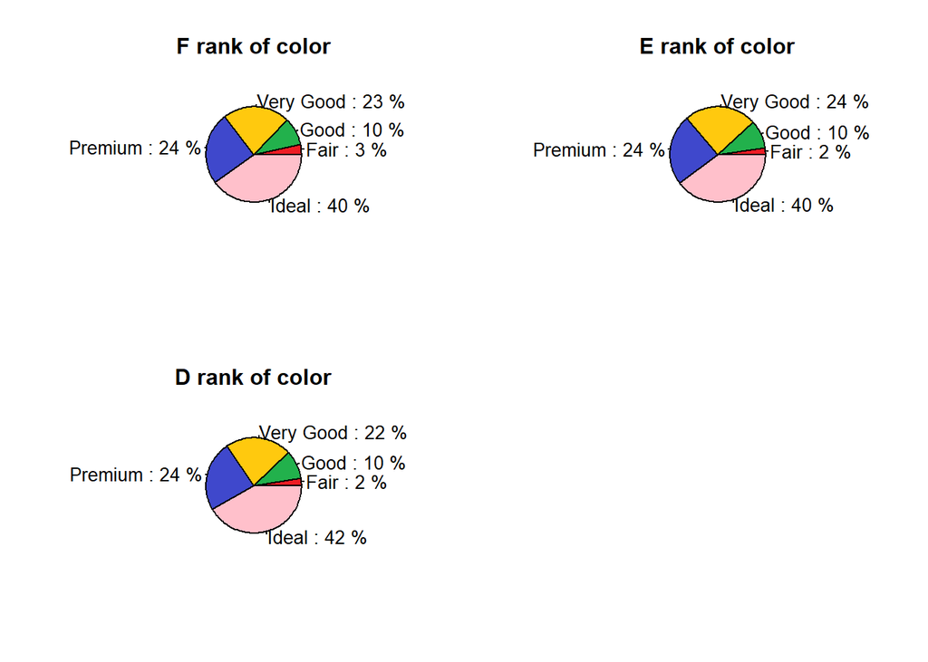

```r
pie(tab_cut_col[5,], labels=piepercent_f, main = "F rank of color", col=cols)
pie(tab_cut_col[6,], labels=piepercent_e, main = "E rank of color", col=cols)
pie(tab_cut_col[7,], labels=piepercent_d, main = "D rank of color", col=cols)
```

Also, we can turn the pie charts to one bar chart to compare the difference.

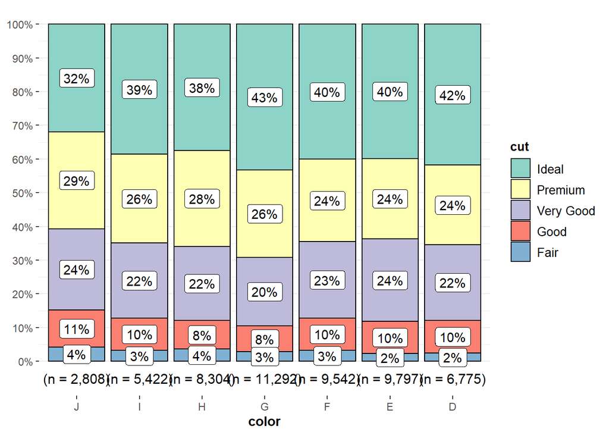

```r
p = ggbarstats(data = diamonds, x = cut, y = color,results.subtitle = F,palette = "Set3", bar.proptest= F)
p
```

On the whole, as the rank of color decreases (from D to J), the proportion of using better cutting methods is also decreasing.  
It seems that the higher ranks of color use greater cutting methods more. In order to obtain evidence to support our conclusion, we performed a Chi-squared test. The result is below. Because the p-value is too small, we have enough evidence to conclude that color of diamonds does affect the cutting methods.

```r
chitest_cut_col = chisq.test(tab_cut_col)
chitest_cut_col
```

```
##
##  Pearson's Chi-squared test
##
## data:  tab_cut_col
## X-squared = 310, df = 24, p-value <2e-16
```

## Conclusion

### How Do Categorical Variables Affect Price?

This was probably the most interesting results we found. It seems that the diamonds in this dataset are statistically more expensive when they have lower quality cuts, colors, and clarity. This is opposite of what logic would tell us when looking at diamonds. There are a few possible explanations for this. One is that our dataset does not have a good spread of data for the the categorical variables, especially for something like cut. However, clarity and color both seem to have enough diamonds in both their lower and higher levels. Another explanation is that bigger diamonds are likely to have lower clarity, cut, and color levels. This is because bigger diamonds are harder to craft to a fine level due to their size. This would explain why bigger, more expensive diamonds have lower cut, clarity, and color qualities.

### How Do Continuous Variables Affect Price?

Our results in this section were difficult to interpret. Since x, y, z, carat, table, and depth are all related to the size of a diamond, these variables had high levels of multicollinearity in models. This made it hard to create linear models using these variables. It was still interesting to look at the results of the two-sample t-tests conducted on price here, and it seems that many of these variables do play a large factor in determining price.

### How Do Categorical Variables Affect Cut?

The results in this section matched up with our expectations the most. Higher clarity levels and higher color levels both equate to higher cut levels.

### Future Research

In the future, it would be interesting to see how the how clarity, cut, and color change with the size of diamonds, to see if our theory on diamond sizes is correct. It would also be interesting to create a predictive model to guess the price or cut of a diamond when given certain other variables. This would allow people to customize their diamond to fit their own budget.

It would also always be good to have more information about diamonds in the future, like the shape of the diamond. This could allow us to do more statistical analysis to see what factors influence diamonds. Lastly, it would be interesting to compare diamonds to other gems, like emeralds, sapphires, rubies, opals, pearls, etc. We are curious if the same factors that affect diamonds affect these gems as well.

## References

Agrawal, S. (2017, May 24). Diamonds. Kaggle.com. (https://www.kaggle.com/shivam2503/diamonds)